# Survey II Assignment

…

# Loading libraries

```r
rm(list = ls())
library(MASS)
library(tidyverse)
library(haven)
library(readxl)
library(xml2)
library(rvest)
library(janitor)
library(DataExplorer)
library(countrycode)
library(explore)
library(lme4)
library(lmerTest)
library(broom.mixed)
library(ggplot2)
library(dplyr)
library(scales)
library(tidyr)
library(kableExtra)
library(gmodels)
library(flexplot)
library(corrplot)
library(DescTools)
library(caret)
library(ROSE)
library(randomForest)
library(pROC)
library(mice)
library(glmnet)
```

# Loading data

## Survey data

```r
data_raw <- read_dta("ZA7575.dta")
```

## Country-level data

This is for joins:

```r
# building a df with country names and codes for the EU-28
codelist <- countrycode::codelist |>
  select(country.name.en, iso.name.en, un.name.en, cow.name, ecb, eurostat, iso2c, iso3c, eu28) |>
  filter(!is.na(eu28))
```

### GDP per capita, PPP (constant 2021 international $)

Retrieved from the World Bank (https://data.worldbank.org/indicator/NY.GDP.PCAP.PP.KD) for the year 2019.

```r
gdp_data <- read_csv("gdp_pc_ppp_2021.csv", skip = 4, show_col_types = FALSE)
head(gdp_data)
```

```
## # A tibble: 6 × 69
##   `Country Name`  `Country Code` `Indicator Name` `Indicator Code` `1960` `1961`
##   <chr>           <chr>          <chr>            <chr>            <lgl>  <lgl>
## 1 Aruba           ABW            GDP per capita,… NY.GDP.PCAP.PP.… NA     NA
## 2 Africa Eastern… AFE            GDP per capita,… NY.GDP.PCAP.PP.… NA     NA
## 3 Afghanistan     AFG            GDP per capita,… NY.GDP.PCAP.PP.… NA     NA
## 4 Africa Western… AFW            GDP per capita,… NY.GDP.PCAP.PP.… NA     NA
## 5 Angola          AGO            GDP per capita,… NY.GDP.PCAP.PP.… NA     NA
## 6 Albania         ALB            GDP per capita,… NY.GDP.PCAP.PP.… NA     NA
## # ℹ 63 more variables: `1962` <lgl>, `1963` <lgl>, `1964` <lgl>, `1965` <lgl>,
## #   `1966` <lgl>, `1967` <lgl>, `1968` <lgl>, `1969` <lgl>, `1970` <lgl>,
## #   `1971` <lgl>, `1972` <lgl>, `1973` <lgl>, `1974` <lgl>, `1975` <lgl>,
## #   `1976` <lgl>, `1977` <lgl>, `1978` <lgl>, `1979` <lgl>, `1980` <lgl>,
## #   `1981` <lgl>, `1982` <lgl>, `1983` <lgl>, `1984` <lgl>, `1985` <lgl>,
## #   `1986` <lgl>, `1987` <lgl>, `1988` <lgl>, `1989` <lgl>, `1990` <dbl>,
## #   `1991` <dbl>, `1992` <dbl>, `1993` <dbl>, `1994` <dbl>, `1995` <dbl>, …
```

```r
gdp_data <- gdp_data |>
  select(`Country Name`, `Country Code`, `2019`)


gdp_data <- gdp_data |>
  rename(country_name = `Country Name`,
         country_code = `Country Code`,
         gdp_pc_ppp = `2019`)

gdp_data <- gdp_data |>
inner_join(select(codelist, iso3c), by = c("country_code" = "iso3c"))

str(gdp_data)
```

```
## tibble [28 × 3] (S3: tbl_df/tbl/data.frame)
##  $ country_name: chr [1:28] "Austria" "Belgium" "Bulgaria" "Cyprus" ...
##  $ country_code: chr [1:28] "AUT" "BEL" "BGR" "CYP" ...
##  $ gdp_pc_ppp  : num [1:28] 64630 60452 27673 46157 47720 ...
```

We now have 28 observations including the UK.

### Rural population

Retrieved from the World Bank (https://data.worldbank.org/indicator/SP.RUR.TOTL.ZS).

Data on the % of population living in rural areas over total population.

```r
rural_data <- read_xls("rural_pop.xls", sheet = 1, range = "A4:BL270")
head(rural_data)
```

```
## # A tibble: 6 × 64
##   `Country Name`  `Country Code` `Indicator Name` `Indicator Code` `1960` `1961`
##   <chr>           <chr>          <chr>            <chr>             <dbl>  <dbl>
## 1 Aruba           ABW            Rural populatio… SP.RUR.TOTL.ZS     49.2   49.2
## 2 Africa Eastern… AFE            Rural populatio… SP.RUR.TOTL.ZS     85.4   85.2
## 3 Afghanistan     AFG            Rural populatio… SP.RUR.TOTL.ZS     91.6   91.3
## 4 Africa Western… AFW            Rural populatio… SP.RUR.TOTL.ZS     85.3   84.9
## 5 Angola          AGO            Rural populatio… SP.RUR.TOTL.ZS     89.6   89.2
## 6 Albania         ALB            Rural populatio… SP.RUR.TOTL.ZS     69.3   69.1
## # ℹ 58 more variables: `1962` <dbl>, `1963` <dbl>, `1964` <dbl>, `1965` <dbl>,
## #   `1966` <dbl>, `1967` <dbl>, `1968` <dbl>, `1969` <dbl>, `1970` <dbl>,
## #   `1971` <dbl>, `1972` <dbl>, `1973` <dbl>, `1974` <dbl>, `1975` <dbl>,
## #   `1976` <dbl>, `1977` <dbl>, `1978` <dbl>, `1979` <dbl>, `1980` <dbl>,
## #   `1981` <dbl>, `1982` <dbl>, `1983` <dbl>, `1984` <dbl>, `1985` <dbl>,
## #   `1986` <dbl>, `1987` <dbl>, `1988` <dbl>, `1989` <dbl>, `1990` <dbl>,
## #   `1991` <dbl>, `1992` <dbl>, `1993` <dbl>, `1994` <dbl>, `1995` <dbl>, …
```

```r
# selecting only the relevant year
rural_data <- rural_data |>
  select(`Country Name`, `Country Code`, `2019`) |>
  clean_names() |>
  rename("rural_pop_percentage" = "x2019")

rural_data <- rural_data |>
  inner_join(select(codelist, iso3c), by = c("country_code" = "iso3c"))

str(rural_data)
```

```
## tibble [28 × 3] (S3: tbl_df/tbl/data.frame)
##  $ country_name        : chr [1:28] "Austria" "Belgium" "Bulgaria" "Cyprus" ...
##  $ country_code        : chr [1:28] "AUT" "BEL" "BGR" "CYP" ...
##  $ rural_pop_percentage: num [1:28] 41.48 1.96 24.65 33.2 26.08 ...
```

### Same sex unions

Retrieved from Wikipedia (https://en.wikipedia.org/wiki/Recognition_of_same-sex_unions_in_Europe).

Table about status of same sex unions by country in Europe.

```r
# scraping the table
marriage_data <- read_html("https://en.wikipedia.org/wiki/Recognition_of_same-sex_unions_in_Europe") |>
  html_table() %>%
  .[[4]] |>
  select(Status, Country)

# cleaning the status column
marriage_data <- marriage_data |>
  mutate(Status = str_remove(Status, "\\s*\\(.*|\\s*-.*")) |>
  filter(!Status %in% c("Total", "Subtotal"))

# cleaning the country column
marriage_data <- marriage_data |>
  mutate(Country = str_replace_all(Country, c("\\*" = "", "†" = "", "\\[.*?\\]" = ""))) |>
  mutate(Country = trimws(Country))

# keeping only eu-28 countries
marriage_data <- marriage_data |>
  inner_join(select(codelist, cow.name), by = c("Country" = "cow.name"))

str(marriage_data)
```

```
## tibble [32 × 2] (S3: tbl_df/tbl/data.frame)
##  $ Status : chr [1:32] "Marriage" "Marriage" "Marriage" "Marriage" ...
##  $ Country: chr [1:32] "Austria" "Belgium" "Denmark" "Estonia" ...
```

This variable could be recoded as either ordinal, categorical (both factor) or logical.

The dataset has 32 observations instead of 28 (EU-28 countries).

```r
marriage_data |>
  add_count(Country) |>
  filter(n > 1)
```

```
## # A tibble: 8 × 3
##   Status                         Country      n
##   <chr>                          <chr>    <int>
## 1 Civil unions                   Croatia      2
## 2 Civil unions                   Hungary      2
## 3 Civil unions                   Latvia       2
## 4 Unregistered cohabitation      Slovakia     2
## 5 Constitutional ban on marriage Croatia      2
## 6 Constitutional ban on marriage Hungary      2
## 7 Constitutional ban on marriage Latvia       2
## 8 Constitutional ban on marriage Slovakia     2
```

According to this test, Croatia, Hungary, Latvia and Slovakia have two different types of status, so maybe we should cross-check with other sources?

Diego: the thing is that countries can at the same time have a constitutional ban on marriage and still have legally recognized civil unions. Thus maybe we should exclude this level from this variable as it is not exclusive. The lowest level would remain no recognition.

Irene: I guess we need to decide whether we think it is more important/representative of a country to have civil unions for same-sex couples or a constitutional ban on same-sex marriage (this feels pretty strong tbh). It depends also on how we want to recode this.

The table is up to date, so I had to check (on Wikipedia honestly) what year each of those items was actually legalized and I got to this:

—————————–same sex marriage—————————–

Greece: civil unions since 2015, marriage since 2024

Estonia: civil unions since 2016, marriage since 2024

Slovenia: civil unions since 2017, marriage since 2022

United Kingdom: marriage since 2014 in England, Scotland and Wales, and since 2020 in Northern Ireland. Civil unions since 2005

———————————civil unions———————————–

Latvia: civil unions since 2024, the Constitution prohibits the recognition of same sex marriage since 2006.

```r
marriage_data <- marriage_data |>
  mutate(Status = case_when(
    Country == "Greece" ~ "Civil Unions",
    Country == "Estonia" ~ "Civil Unions",
    Country == "Slovenia" ~ "Civil Unions",
    Country == "United Kingdom" ~ "Civil Unions" ,  # I understand that same-sex marriage wasn't legal in the UK until it was legalised in all of its territories, but this can be discussed
    Country == "Latvia" & Status == "Civil unions" ~ "No recognition", # only mutate one of the rows that Latvia is in
    # Latvia had no recognition prior to 2024, but it has a constitutional ban on marriage, which is a category that we found alongside others in some observations, so we'll keep two rows for Latvia for now
    TRUE ~ Status
  ))

marriage_data |> filter(Country %in% c("Latvia", "Greece", "Estonia", "Slovenia", "United Kingdom"))
```

```
## # A tibble: 6 × 2
##   Status                         Country
##   <chr>                          <chr>
## 1 Civil Unions                   Estonia
## 2 Civil Unions                   Greece
## 3 Civil Unions                   Slovenia
## 4 Civil Unions                   United Kingdom
## 5 No recognition                 Latvia
## 6 Constitutional ban on marriage Latvia
```

I also found this LGBT rights index on Our World in Data (https://ourworldindata.org/grapher/lgbt-rights-index) which captures whether LGBT+ people enjoy the same rights as cisgender people combining information on 18 different policies. It includes the legal status of same-sex marriage so we might keep only one of these.

```r
lgbt_rights_index <- read.csv("lgbt-rights-index.csv")

lgbt_rights_index <- lgbt_rights_index |>
  filter(Year == 2019) |>
  inner_join(select(codelist, iso3c), by = c("Code" = "iso3c")) |>
  select(-Year) # all observations are from 2019

str(lgbt_rights_index)
```

```
## 'data.frame':    28 obs. of  3 variables:
##  $ Entity            : chr  "Austria" "Belgium" "Bulgaria" "Croatia" ...
##  $ Code              : chr  "AUT" "BEL" "BGR" "HRV" ...
##  $ LGBT..Policy.Index: num  8.92 10 4.94 6.96 3.95 ...
```

Column names can be renamed:

```r
lgbt_rights_index <- lgbt_rights_index |>
  rename(country_name = Entity,
         country_code = Code,
         lgbt_policy_index = LGBT..Policy.Index)
```

### Gender inequality index

Gender Development and Gender Inequality indexes, developed by the United Nations Development. Retrieved from https://hdr.undp.org/data-center/documentation-and-downloads for the year 2019.

```r
gender_index <- read_xlsx("UNDP_gender_indexes.xlsx")

gender_index <- gender_index |>
  select(-dimension, -note, -year) |> # empty/useless columns
  inner_join(select(codelist, iso3c), by = c("countryIsoCode" = "iso3c"))

gender_index |>
  distinct(country) |>
  nrow()
```

```
## [1] 28
```

```r
str(gender_index)
```

```
## tibble [560 × 7] (S3: tbl_df/tbl/data.frame)
##  $ countryIsoCode: chr [1:560] "AUT" "AUT" "AUT" "AUT" ...
##  $ country       : chr [1:560] "Austria" "Austria" "Austria" "Austria" ...
##  $ indexCode     : chr [1:560] "GII" "GDI" "GDI" "GDI" ...
##  $ index         : chr [1:560] "Gender Inequality Index" "Gender Development Index" "Gender Development Index" "Gender Development Index" ...
##  $ indicatorCode : chr [1:560] "abr" "eys_f" "eys_m" "gdi" ...
##  $ indicator     : chr [1:560] "Adolescent Birth Rate (births per 1,000 women ages 15-19)" "Expected Years of Schooling, female (years)" "Expected Years of Schooling, male (years)" "Gender Development Index (value)" ...
##  $ value         : num [1:560] 5.499 16.451 15.725 0.969 0.053 ...
```

We checked that we have indeed 28 distinct countries in the dataset.

This dataset collects many indicators apart from the indexes values. We are selecting only the Gender Development and Gender Inequality indexes (GDI and GII):

```r
gender_index <- gender_index |>
  filter(indicatorCode %in% c("gdi", "gii")) |>
  select(-c(indexCode, indicatorCode, indicator)) |> # removing redundant columns
  pivot_wider(names_from = index, values_from = value)

colnames(gender_index) <- janitor::make_clean_names(colnames(gender_index)) # cleaning spaces and upper cases
```

And then exploring them to see which one is a better fit for modeling and predictions:

```r
summary(gender_index$gender_inequality_index)
```

```
##    Min. 1st Qu.  Median    Mean 3rd Qu.    Max.
##  0.0160  0.0555  0.0890  0.1067  0.1335  0.2390
```

```r
summary(gender_index$gender_development_index)
```

```
##    Min. 1st Qu.  Median    Mean 3rd Qu.    Max.
##  0.9560  0.9725  0.9855  0.9856  0.9918  1.0230
```

```r
sd(gender_index$gender_inequality_index)
```

```
## [1] 0.06664423
```

```r
sd(gender_index$gender_development_index)
```

```
## [1] 0.0167627
```

We observe that the second one (Gender Development Index) has a very small range, indicating that most countries have nearly identical scores. This is supported by the standard deviation, which shows that the GII is more spread out than the GDI. Being almost constant, GDI won’t add much value to the analysis. This is likely due to the fact that these indexes are created by the United Nations Development Programme for all countries, so it may not capture the finer differences between EU countries.

```r
cor(gender_index$gender_inequality_index,
    gender_index$gender_development_index,
    use = "complete.obs")
```

```
## [1] 0.1750589
```

Surprisingly, the two indexes have a very weak positive correlation. While they are not inverse, I was expecting them to measure opposite things, so maybe the correlation coefficient is not useful here because of the low variation of both variables (specially GDI). I don’t know what else to do with this info other than keeping GII and discarding GDI.

```r
gender_index <- gender_index |>
  select(-gender_development_index)
```

### Economist’s Democracy Index

```r
democracy_index <- read_xlsx("EIU_democracy_index.xlsx", sheet = 4)

# the ISO codes were lowercase which impedes the join
democracy_index$geo <- toupper(democracy_index$geo)

# filter for 2019 and EU28 countries
democracy_index <- democracy_index |>
  filter(time == 2019) |>
  inner_join((select(codelist, iso3c)), by = c("geo" = "iso3c"))

# clean var names
names(democracy_index) <- names(democracy_index) %>%
  janitor::make_clean_names() %>%
  gsub("_eiu$", "", .)

democracy_index <- democracy_index |>
  rename(country_code = geo,
         country_name = name,
         year = time)

str(democracy_index)
```

```
## tibble [28 × 10] (S3: tbl_df/tbl/data.frame)
##  $ country_code                 : chr [1:28] "AUT" "BEL" "BGR" "HRV" ...
##  $ country_name                 : chr [1:28] "Austria" "Belgium" "Bulgaria" "Croatia" ...
##  $ year                         : num [1:28] 2019 2019 2019 2019 2019 ...
##  $ democracy_index              : num [1:28] 82.9 76.4 70.3 65.7 75.9 76.9 92.2 79 92.5 81.2 ...
##  $ electoral_pluralism_index    : num [1:28] 95.8 95.8 91.7 91.7 91.7 95.8 100 95.8 100 95.8 ...
##  $ government_index             : num [1:28] 78.6 82.1 64.3 60.7 64.3 67.9 92.9 78.6 89.3 78.6 ...
##  $ political_participation_index: num [1:28] 83.3 50 72.2 55.6 66.7 66.7 83.3 66.7 88.9 77.8 ...
##  $ political_culture_index      : num [1:28] 68.8 68.8 43.8 50 68.8 68.8 93.8 68.8 87.5 68.8 ...
##  $ civil_liberties_index        : num [1:28] 88.2 85.3 79.4 70.6 88.2 85.3 91.2 85.3 97.1 85.3 ...
##  $ change_in_democracy_index    : num [1:28] 0 -1.4 0 0 0 ...
```

```r
democracy_index <- democracy_index |>
  select(country_name, country_code, democracy_index)
```

#### Joining all country-level data together

```r
country_level_data <- codelist |>
  select(iso3c, iso2c) |>
  left_join(gdp_data, by = c("iso3c" = "country_code")) |>
  # left_join(rural_data, by = c("iso3c" = "country_code")) |> rural population data will probably be discarded
  left_join(gender_index, by = c("iso3c" = "country_iso_code")) |>
  left_join(lgbt_rights_index, by = c("iso3c" = "country_code")) |>
  left_join(democracy_index, by = c("iso3c" = "country_code")) |>
  select(-contains("country_")) # removing all duplicated country_name columns that were joined from each data frame
str(country_level_data)
```

```
## tibble [28 × 7] (S3: tbl_df/tbl/data.frame)
##  $ iso3c                  : chr [1:28] "AUT" "BEL" "BGR" "HRV" ...
##  $ iso2c                  : chr [1:28] "AT" "BE" "BG" "HR" ...
##  $ gdp_pc_ppp             : num [1:28] 64630 60452 27673 35094 46157 ...
##  $ country                : chr [1:28] "Austria" "Belgium" "Bulgaria" "Croatia" ...
##  $ gender_inequality_index: num [1:28] 0.053 0.048 0.205 0.119 0.235 0.124 0.016 0.092 0.031 0.086 ...
##  $ lgbt_policy_index      : num [1:28] 8.92 10 4.94 6.96 3.95 ...
##  $ democracy_index        : num [1:28] 82.9 76.4 70.3 65.7 75.9 76.9 92.2 79 92.5 81.2 ...
```

# Data cleaning

## Selecting relevant variables in the survey data

We are discarding all variables that relate to trade and globalization as deemed not relevant for our analysis `qa`. We are also discarding variables related to energy policies `qb`.

We have also not considered questions specifically about Roma ex `qc8` and `qc14` and `qc16`

Some of the doubts we had:

AGE

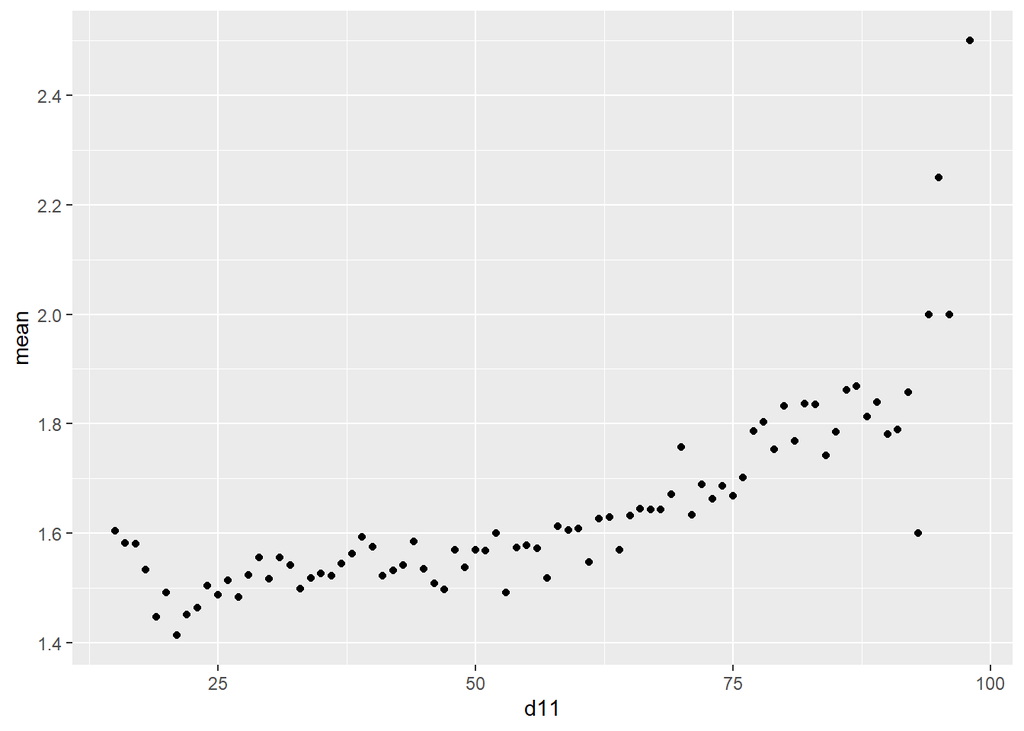

```r
x_df <- data_raw |> summarise(mean = mean(qc19), .by = d11)
ggplot(x_df, aes(x = d11, y = mean)) + geom_point()
```

POLITICAL OPINIONS

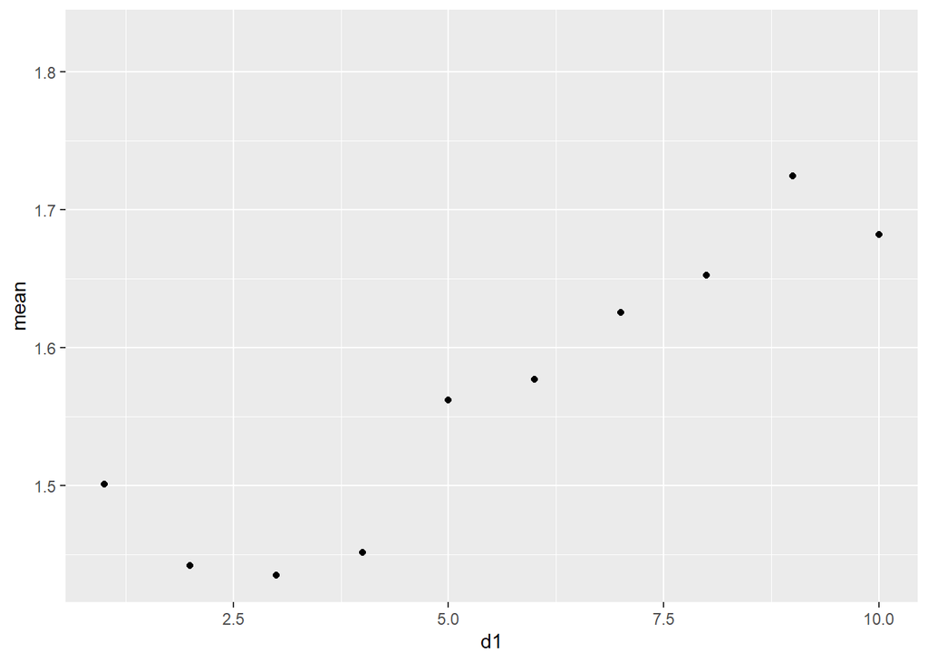

```r
x_df <- data_raw |> summarise(mean = mean(qc19), .by = d1)
ggplot(x_df, aes(x = d1, y = mean)) + geom_point() + xlim(1,10)
```

MARRIAGE

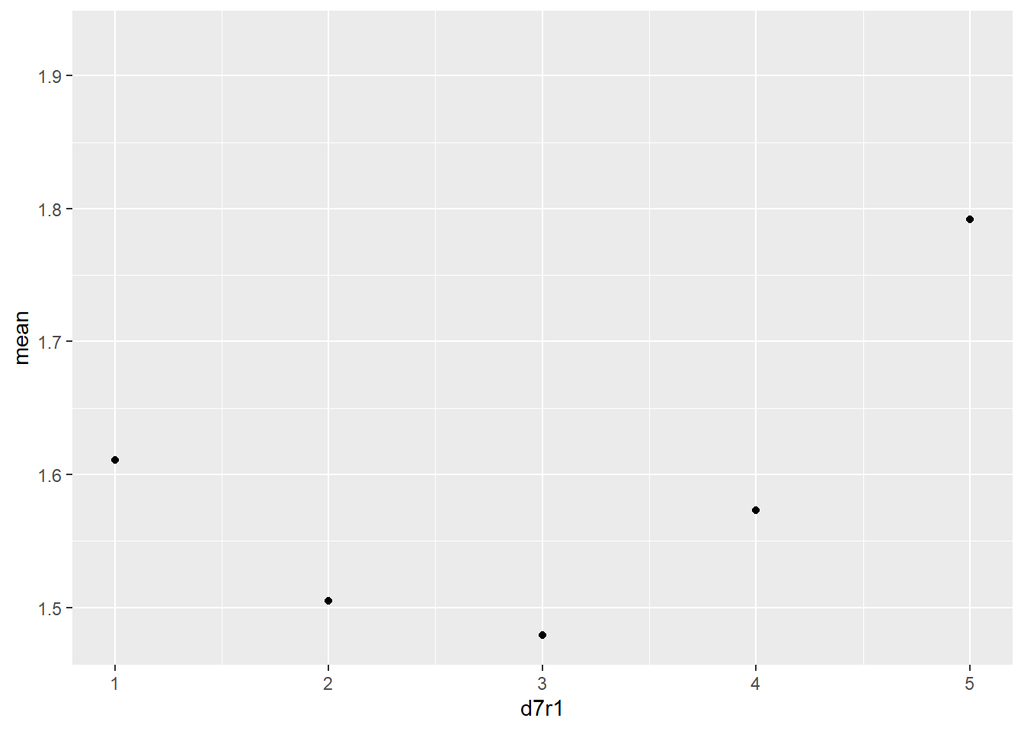

```r
x_df <- data_raw |> summarise(mean = mean(qc19), .by = d7r1)
ggplot(x_df, aes(x = d7r1, y = mean)) + geom_point() + xlim(1,5)
```

Of all the possible combinations this one seems the best to highlight differences in our target variable

NATIONALITY

There is no easy way to create an immigrant dummy by checking whether someone does not have the nationality of the country in which he is being interviewed for the survey. So we are just going to use `q1_29` as a dummy for whether someone owns a non-EU nationality

POLITICAL INTEREST

Using only `polintr` as a summary of the whole `d71` question about how strong is your interest in politics in various domains

EXPERIENCED DISCRIMINATION

For the questions about whether you have experienced discrimination `qc2_` I am keeping only `qc2_15` which is a binary on whether you have experienced any discrimination or not and I am not keeping the other categories that allowed us to understand if you had experienced discrimination on the basis of a particular motive. We can probably assume that if a person is a part of a specific minority (info from `sd2`) and is being discriminated is because of being part of that minority (at least in most cases), therefore it felt like information we already had (and which we can easily put in our regression using interaction effects)

PERCIEVED DISCRIMINATION in country

This is a question (`qc1`) about how widespread you perceived discrimination is in your country. It is a rather peculiar question because it asks individUals for perception at the country level. I think it might be more useful (by aggregating results by country) to use it to build a country level indicator of perceived discrimination against certain minorities that are of our interest rather than use it as an individual level variable. So I will keep them out of the dataset for now

For the same reason I am also discarding `qc4` that asks whether in your country you feel like candidates with certain characteristics would be at a disadvantage in the recruitment process. It still basically asks about perceived discrimination at the country level.

And the same reasoning also applies to `qc7` which asks if efforts towards reducing discrimination are effective in your country.

HOW DISCRIMINATORY ARE YOU score

I use `qc12` and `qc13` to build a score from 1 to 10 of how discriminatory are you against certain minorities. I am building the score for each minority and then we can decide later if some are irrelevant.

Note for some categories this score is a bit stupid (ex. voting for whether you would feel uncomfortable if your child was in a love relationship with a old person would give you a high racist score against old people, this is an example of some of the categories for which it is worth excluding the index)

We can also further aggregate to obtain just one score (or obtain religious/ethnic score etc.).

Option also to discard them all (anti lgbtqi sentiment is also captured in the next index built from `qc15`)

`qc6` also asks about discriminatory behaviors, but is about elected public official, it does not ask about a situation that impacts you personally. It also uses different categories for minorities therefore I prefer to use `qc12` and `qc13` rather than `qc6`

SUPPORTIVE OF LGBTQ RIGHTS INDEX

Using `qc15` we can again build an index for how supportive of lgbtq rights a person is.

I again choose to take the mean across the different answers but we could also use median/mode if we think is better

If we feel each or some answers are particularly useful (given they are closely related with our target variable) we can also use them separately

We could also use `qc18` to try to capture anti lgbtq sentiment, but I preferred `qc15` as it seemed more straightforward (I therfore deleted `qc18`, but we can put it back if useful)

MY VOICE COUNTS

I guess that people that feel alienated from society and politics might be less likely to support lgbtq rights so I took the mean of `d72` question which asked whether you felt like your voice mattered

OTHERS

`qc11` is a strange question feels useless to me, I removed it for now but we can think about it

I also removed `qc9` as I don’t really know what to do with it and `qc17`

```r
data <- data_raw |>
  select(serialid, # unique identifier
         isocntry, # 2 digit country code
         d11, # age variables
         q1_29, # nationality of interviewee. options given: EU28+Other+DK, using only other = outside of EU
         d70, #life satisfaction
         polintr, # political interest index (summarizes d71 questions)
         starts_with("sd1"), # friends that are minority groups
         starts_with("sd2"), # are you part of a minority
         sd3, # religion
         qc2_15, # experienced discrimination yourself
         qc3, # where discrimination took place
         starts_with("qc5"), # actions against discrimination
         qc10, # how would you report discrimination
         starts_with("qc12"), # feelings about colleagues being minority
         starts_with("qc13"), # feelings about kid being in a relationship with minority
         starts_with("qc15"), # opinions about lgbtqi
         qc19, # target variable transgender
         qc20, # non-binary genders in documents
         d1r1, # political ideology
         d7r1, # marital status
         d10, # gender binary
         d8, # eduaction
         d15a_r2, # current occupation (discarded previous occupation d15b)
         d25, # rural vs urban
         d43t, # phones availiabilty
         d60, # financial stress (paying bills)
         netuse, # internet index
         d63, # social class
         starts_with("d72"), # my voice counts
  )

paradata <- data_raw |>
  select(serialid, # to match it with the other data
         p2, p3, p3r, p4, p5, # paradata)
  )
```

Removing some of the previously selected variables

`sd2_7` to `sd2_10`: these are possible answer deemed irrelevant to the question about yourself being part of the following minorities: `sd2_7` other minorities (I don’t know what other relevant minorities could be there), `sd2_8` not part of minorities (can be deducted from the rest), `sd2_9` refusal to respond, `sd2_10` DK answers `sd2t` summary binary variable for being part of any minority (we are going to keep the more specific one)

I also remove `qc12_nr` as I prefer to work on the full variable instead of the recoded version with less categories. Same for `qc13` and `qc18`

```r
data <- data |>
  # Keep in mind that sd2t does not have NAs so we might want to use that instead of the more specific ones
  select(-c(sd2_7, sd2_8, sd2_9, sd2_10, sd2t)) |>
  select(-(starts_with("qc12") & ends_with("r"))) |>
  select(-(starts_with("qc13") & ends_with("r"))) |>
  select(-(starts_with("qc18") & ends_with("r")))
```

## Check overall data quality

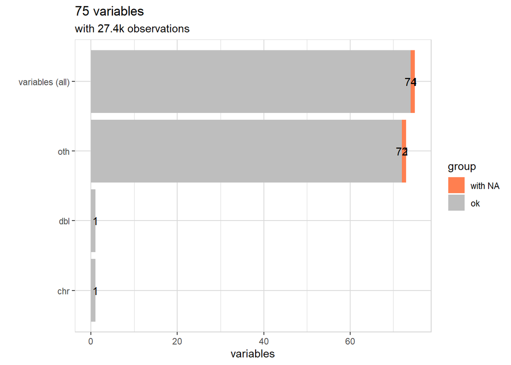

```r
explore_tbl(data)
```

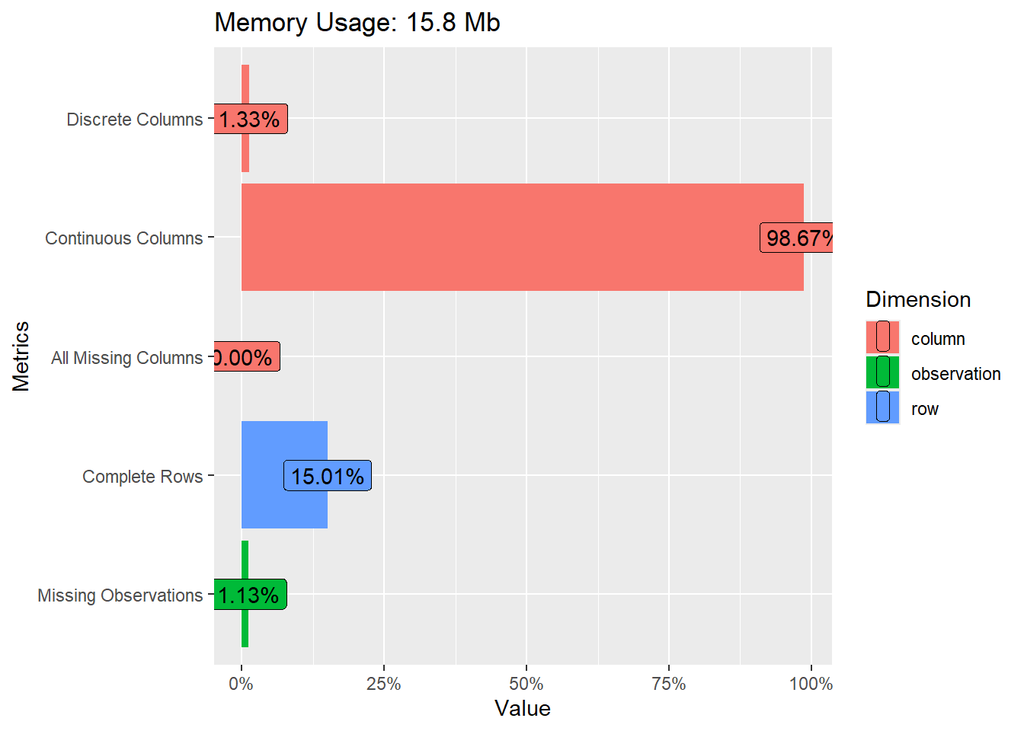

```r
plot_intro(data)
```

All columns are numeric columns, the only one which is not is `isocntry`

```r
data |>
  select(where(~ !is.numeric(.)))
```

```
## # A tibble: 27,438 × 1
##    isocntry
##    <chr>
##  1 BE
##  2 BE
##  3 BE
##  4 BE
##  5 BE
##  6 BE
##  7 BE
##  8 BE
##  9 BE
## 10 BE
## # ℹ 27,428 more rows
```

Most columns do not have explicit NAs

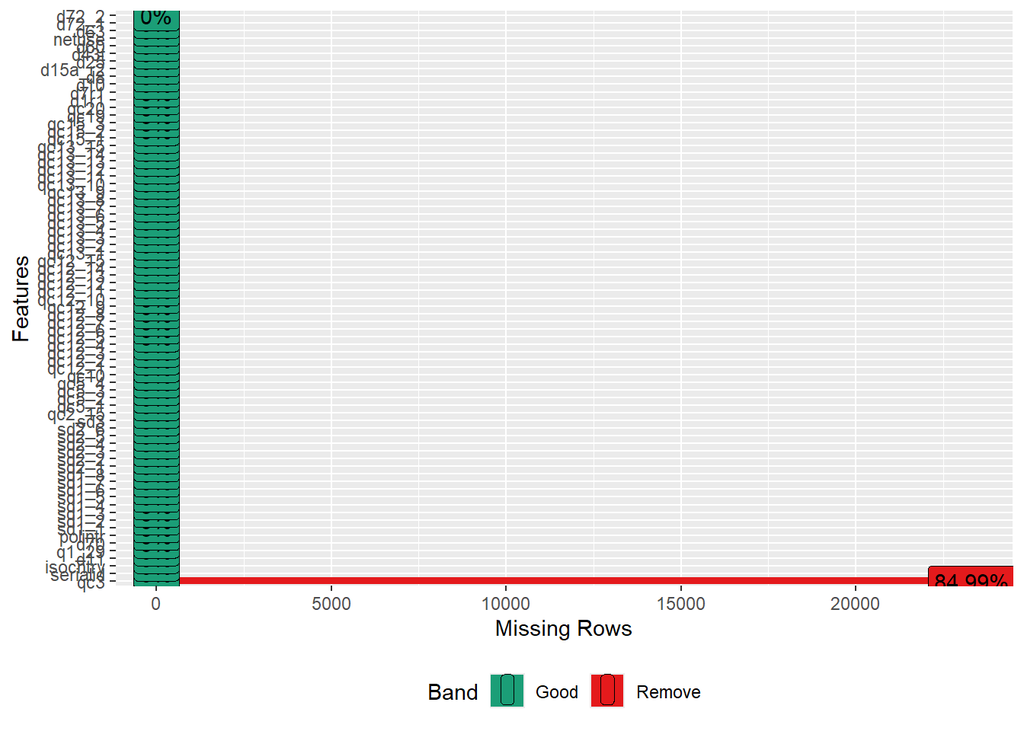

```r
plot_missing(data)
```

```r
names(which(colSums(is.na(data)) > 0))
```

```
## [1] "qc3"
```

Exploiting the fact that the .dta files has attributes (labels) for all its columns.

If we search for `attr(colname, "label")` you get back the original long name of the variable

If we instead search for `attr(colname, "labels")` you get back all the possible encoding levels of the variable (ex.1,2,3,4 etc.) and by doing `names(attr(colname, "labels"))` you get back the actual meaning of those numbers (ex. 1 = “Yes”, 2 = “No”, etc.)

```r
# Extracting all the full names of the columns
variable_names <- tibble(
  var_code = names(data),
  var_full_name = sapply(data, function(col) attr(col, "label")))
variable_names
```

```
## # A tibble: 75 × 2
##    var_code var_full_name
##    <chr>    <chr>
##  1 serialid SERIAL CASE ID (PROVIDED BY KANTAR)
##  2 isocntry COUNTRY CODE - ISO 3166
##  3 d11      AGE EXACT
##  4 q1_29    NATIONALITY: OTHER COUNTRIES
##  5 d70      LIFE SATISFACTION
##  6 polintr  POLITICAL INTEREST INDEX (D71 SUMMARIZED)
##  7 sd1_1    CONTACT: PEOPLE OF DIFFERENT ETHNIC ORIGIN
##  8 sd1_2    CONTACT: PEOPLE OF DIFFERENT SKIN COLOUR
##  9 sd1_3    CONTACT: ROMA
## 10 sd1_4    CONTACT: GAY LESBIAN OR BISEXUAL
## # ℹ 65 more rows
```

These long names df might be useful to rename the variables systematically all together. Remember in case we filter out variables after this code chunk and in case we use this df to rename variables that there might be disalignments.

Will now look into the labels for the different levels that our factor variables can take:

```r
attr(data$d70, "labels")
```

```
##       Very satisfied     Fairly satisfied   Not very satisfied
##                    1                    2                    3
## Not at all satisfied                   DK
##                    4                    5
```

```r
names(attr(data$d70, "labels"))
```

```
## [1] "Very satisfied"       "Fairly satisfied"     "Not very satisfied"
## [4] "Not at all satisfied" "DK"
```

```r
tibble(name_labels = names(attr(data$d70, "labels")),
       labels = attr(data$d70, "labels"))
```

```
## # A tibble: 5 × 2
##   name_labels          labels
##   <chr>                 <dbl>
## 1 Very satisfied            1
## 2 Fairly satisfied          2
## 3 Not very satisfied        3
## 4 Not at all satisfied      4
## 5 DK                        5
```

```r
# Create a list of tibbles containing the labels and their associated name for each variable
list_label_tibbles <-
  #Applies a function across all columns of a df and returns results as a list
  lapply(names(data), function(col_name) {
    labels <- attr(data[[col_name]], "labels")  # Extract labels
    name_labels <- names(labels)  # Extract label names
    # Create tibble with the extracted data only if labels exist
    if (!is.null(labels)) {
      tibble(name_labels = name_labels, labels = labels)}
    else {NULL}  # Returns a NULL element for columns without labels
  })

# Giving to each element of the list as name the name of the variable
list_label_tibbles <- setNames(list_label_tibbles, names(data))

# For example
list_label_tibbles$d70
```

```
## # A tibble: 5 × 2
##   name_labels          labels
##   <chr>                 <dbl>
## 1 Very satisfied            1
## 2 Fairly satisfied          2
## 3 Not very satisfied        3
## 4 Not at all satisfied      4
## 5 DK                        5
```

Right column is what it appears in our data (as a number). Left column is the label that we must assign to that number when we factorize

## Cleaning

### Initial cleaning and pre-processing

```r
# Recoding together Germany East and West because we are running analysis at the country level
unique(data$isocntry)
```

```
##  [1] "BE"   "DK"   "GR"   "ES"   "FI"   "FR"   "IE"   "IT"   "LU"   "NL"
## [11] "AT"   "PT"   "SE"   "DE-W" "DE-E" "GB"   "BG"   "CY"   "CZ"   "EE"
## [21] "HU"   "LV"   "LT"   "MT"   "PL"   "RO"   "SK"   "SI"   "HR"
```

```r
data <- data |>
  mutate(isocntry = case_when(
    isocntry %in% c("DE-W", "DE-E") ~ "DE",
    TRUE ~ isocntry))
# We might want to join the full name of the countries using the codelist df
```

Separating variables for which I can use the attribute labels to factorize them and the variables for which this strategy cannot be used

```r
data <- data |>
  rename(friends_trans = sd1_7)

non_factor_variables <- c("serialid", "tnscntry", "isocntry", "d11", "q1_29",
                          names(data)[startsWith(names(data), "sd1_")],
                          names(data)[startsWith(names(data), "sd2_")],
                          names(data)[startsWith(names(data), "qc5_")],
                          names(data)[startsWith(names(data), "qc12_")],
                          names(data)[startsWith(names(data), "qc13_")],
                          names(data)[startsWith(names(data), "qc15_")],
                          names(data)[startsWith(names(data), "d72_")],
                          "d8", "opls")
factor_variables <- setdiff(names(data), non_factor_variables)
```

Correctly encoding the factor variables that do not need any further cleaning

```r
# Converting them to factors and assign them their labels automatically
data <- data |>
  mutate(across(all_of(factor_variables), labelled::to_factor))

# Turning DK into NAs for all the factor variables
data <- data |>
  mutate(across(all_of(factor_variables), ~ fct_na_level_to_value(., extra_levels = "DK")))

# Converting to numeric the variables that should be numeric
# They are already numeric but they carry with them some labels as well that only confuse us, by doing this I remove the labels
data <- data |>
  mutate(age = as.numeric(d11),
         years_edu = as.numeric(d8)) |>
  # Recoding correctly d8 education variable according to unique(data_raw$d11))
  mutate(years_edu = case_when(
    years_edu %in% c(0, 99) ~ NA, # Refusal and DK as NAs
    years_edu == 97 ~ 0, # No full time education = 0
    years_edu == 98 ~ age, # still studying = age
    TRUE ~ years_edu)) |>
  select(-c(d11, d8))

# Converting q1_29 to factor without assigning labels (1 if non-Eu nationality, 0 if EU nationality)
# Same for sd2_
data <- data |>
  mutate(nonEU_national = as.factor(q1_29),
         across(starts_with("sd2_"), ~ as.factor(.x))) |>
  select(-q1_29)
```

Dealing with the other variables on which we do some further pre-processing (feature engineering)

```r
# Creating a variable that counts the number of different minority groups a person has acquaintances with
data <- data |>
  mutate(across(starts_with("sd1"), ~ if_else(.x == 1, 1, 0))) |>
  mutate(n_friends_minorities = sd1_1+sd1_2+sd1_3+sd1_4+sd1_5+sd1_6+sd1_8) |>
  relocate(n_friends_minorities, .before="sd1_1") |>
  select(-starts_with("sd1"))

# Creating a variable that counts the number of actions against discrimination that you have taken in the last year
data <- data |>
  mutate(across(starts_with("qc5"), ~ if_else(.x == 1, 1, 0))) |>
  mutate(n_actions_against_discri = qc5_1+qc5_2+qc5_3+qc5_4) |>
  relocate(n_actions_against_discri, .after="qc3") |>
  select(-starts_with("qc5"))
```

```r
# Building a discriminatory score
data <- data |>
  # Coding as NAs "it depends" and "DK"
  mutate(across(starts_with("qc12"), ~ if_else(.x >= 12, NA, .x))) |>
  mutate(across(starts_with("qc13"), ~ if_else(.x >= 12, NA, .x))) |>
  # Coding as 5 responses = indifferent
  mutate(across(starts_with("qc12"), ~ if_else(.x == 11, 5, .x))) |>
  mutate(across(starts_with("qc13"), ~ if_else(.x == 11, 5, .x))) |>
  # Modifying such that higher is more discriminatory
  mutate(roma_discri = 11 - rowMeans(cbind(qc12_1, qc13_1), na.rm = TRUE),
         black_discri = 11 - rowMeans(cbind(qc12_2, qc13_2), na.rm = TRUE),
         asian_discri = 11 - rowMeans(cbind(qc12_3, qc13_3), na.rm = TRUE),
         white_discri = 11 - rowMeans(cbind(qc12_4, qc13_4), na.rm = TRUE),
         jewish_discri = 11 - rowMeans(cbind(qc12_5, qc13_5), na.rm = TRUE),
         muslim_discri = 11 - rowMeans(cbind(qc12_6, qc13_6), na.rm = TRUE),
         buddihst_discri = 11 - rowMeans(cbind(qc12_7, qc13_7), na.rm = TRUE),
         christian_discri = 11 - rowMeans(cbind(qc12_8, qc13_8), na.rm = TRUE),
         atheist_discri = 11 - rowMeans(cbind(qc12_9, qc13_9), na.rm = TRUE),
         lgb_discri = 11 - rowMeans(cbind(qc12_10, qc13_10), na.rm = TRUE),
         trans_discri = 11 - rowMeans(cbind(qc12_11, qc13_11), na.rm = TRUE),
         intersex_discri = 11 - rowMeans(cbind(qc12_12, qc13_12), na.rm = TRUE),
         disability_discri = 11 - rowMeans(cbind(qc12_13, qc13_13), na.rm = TRUE),
         young_discri = 11 - rowMeans(cbind(qc12_14, qc13_14), na.rm = TRUE),
         old_discri = 11 - rowMeans(cbind(qc12_15, qc13_15), na.rm = TRUE)) |>
  select(-starts_with("qc12")) |>
  select(-starts_with("qc13"))

# I am deleting the discrimination index against young and old people
# This is because one of the question is: how comfortable you would feel if one of your children was in a love relationship with a person from group x.
# It is totally acceptable that people would not feel comfortable with their kid dating an old person without that accounting for being discriminatory against old people
data <- data |>
  select(-c("old_discri", "young_discri"))
```

```r
# Supportive of lbtq rights index
data <- data |>
  mutate(across(starts_with("qc15"), ~ if_else(.x == 5, NA, .x))) |>
  # Scale of 1 to 4, 1 = supportive, 4 = homophobic
  mutate(antilgbtq_rights = round(rowMeans(cbind(qc15_1, qc15_2, qc15_3), na.rm = TRUE), 2)) |>
  select(-starts_with("qc15"))
```

```r
# My voice counts index
data <- data |>
  mutate(across(starts_with("d72"), ~ if_else(.x > 4, NA, .x))) |>
  mutate(social_alienation = rowMeans(cbind(d72_1, d72_2), na.rm = TRUE)) |>
  select(-starts_with("d72"))
# The higher the more people think their voice does not matter
```

This should be our final selection of variables.

We still need to rename them appropriately and check that all the NAs are correctly encoded by looking at the summary.

Rename columns appropriately and move them around to order the dataframe

```r
data <- data |>
  rename(
    country = isocntry,
    life_sat = d70,
    ethnic_minority = sd2_1,
    skincolor_minority = sd2_2,
    religious_minority = sd2_3,
    roma_minority = sd2_4,
    sexual_minority = sd2_5,
    disability_minority = sd2_6,
    religion = sd3,
    disc = qc2_15,
    disc_where = qc3,
    disc_contact = qc10,
    trans_docs = qc19,
    gender_docs = qc20,
    left_right = d1r1,
    marital_status = d7r1,
    gender = d10,
    occupation = d15a_r2,
    community = d25,
    phone_access = d43t,
    bill_issues = d60,
    internet_use = netuse,
    social_class = d63
  )
```

Now, we will transform the variable disc, which was originally coded in a negative way (1 = “Not mentioned”, 2 = “No, you haven’t been discriminated against”), into a positive dummy variable to make its interpretation more straightforward. The variable is 1 if a person has been subject to discrimination

```r
data <- data |>
  mutate(suffered_discr = as.factor(ifelse(disc == "Not mentioned", 1, 0))) |>
  select(-disc) |>
  relocate(suffered_discr, .before = disc_where)
```

```r
# Relocating to have a ordered df
data <- data |>
  relocate(c("age", "gender", "years_edu","community", "marital_status", "occupation", "social_class", "religion", "nonEU_national", "phone_access", "bill_issues", "internet_use"), .after = country) |>
  relocate(c("left_right", "social_alienation"), .after = polintr) |>
  relocate(c("friends_trans", "n_friends_minorities", "n_actions_against_discri"), .after = gender_docs)

# Assigning labels to columns which have a difficult meaning
attr(data$gender, "label") <- NULL
attr(data$nonEU_national, "label") <- "OWNS A NON-EU NATIONALITY"
attr(data$social_alienation, "label") <- "HIGHER -> THINK THEIR VOICE DOESN'T  MATTER"
attr(data$ethnic_minority, "label") <- "ARE YOU PART OF X MINORITY"
attr(data$skincolor_minority, "label") <- "ARE YOU PART OF X MINORITY"
attr(data$religious_minority, "label") <- "ARE YOU PART OF X MINORITY"
attr(data$roma_minority, "label") <- "ARE YOU PART OF X MINORITY"
attr(data$sexual_minority, "label") <- "ARE YOU PART OF X MINORITY"
attr(data$disability_minority, "label") <- "ARE YOU PART OF X MINORITY"
attr(data$disability_minority, "label") <- "ARE YOU PART OF X MINORITY"
attr(data$disability_minority, "label") <- "ARE YOU PART OF X MINORITY"
attr(data$suffered_discr, "label") <- "HAVE YOU BEEN SUBJECT TO DISCRIMINATION"
attr(data$n_friends_minorities, "label") <- "YOU KNOW PEOPLE FROM # NUMBER OF DIFFERENT MINORITES"
attr(data$n_actions_against_discri, "label") <- "YOU HAVE DONE # NUMBER OF DIFFERENT ACTIONS TO FIGHT DISCRIMINATIONS"
attr(data$roma_discri, "label") <- "HOW DISCRIMINATORY ARE YOU AGAINST X"
attr(data$black_discri, "label") <- "HOW DISCRIMINATORY ARE YOU AGAINST X"
attr(data$asian_discri, "label") <- "HOW DISCRIMINATORY ARE YOU AGAINST X"
attr(data$white_discri, "label") <- "HOW DISCRIMINATORY ARE YOU AGAINST X"
attr(data$jewish_discri, "label") <- "HOW DISCRIMINATORY ARE YOU AGAINST X"
attr(data$muslim_discri, "label") <- "HOW DISCRIMINATORY ARE YOU AGAINST X"
attr(data$buddihst_discri, "label") <- "HOW DISCRIMINATORY ARE YOU AGAINST X"
attr(data$christian_discri, "label") <- "HOW DISCRIMINATORY ARE YOU AGAINST X"
attr(data$atheist_discri, "label") <- "HOW DISCRIMINATORY ARE YOU AGAINST X"
attr(data$atheist_discri, "label") <- "HOW DISCRIMINATORY ARE YOU AGAINST X"
attr(data$lgb_discri, "label") <- "HOW DISCRIMINATORY ARE YOU AGAINST X"
attr(data$trans_discri, "label") <- "HOW DISCRIMINATORY ARE YOU AGAINST X"
attr(data$intersex_discri, "label") <- "HOW DISCRIMINATORY ARE YOU AGAINST X"
attr(data$disability_discri, "label") <- "HOW DISCRIMINATORY ARE YOU AGAINST X"
attr(data$antilgbtq_rights, "label") <- "HIGHER -> THEY OPPOSE MORE RIGHTS TO LGBTQ"
```

```r
summary(data)
```

```
##     serialid       country               age          gender
##  Min.   :    1   Length:27438       Min.   :15.00   Man  :12492
##  1st Qu.: 6860   Class :character   1st Qu.:37.00   Woman:14946
##  Median :13720   Mode  :character   Median :53.00
##  Mean   :13720                      Mean   :51.56
##  3rd Qu.:20579                      3rd Qu.:66.00
##  Max.   :27438                      Max.   :98.00
##
##    years_edu                          community
##  Min.   : 0.00   Rural area or village     : 8776
##  1st Qu.:17.00   Small or middle sized town:10767
##  Median :18.00   Large town                : 7881
##  Mean   :19.66   NA's                      :   14
##  3rd Qu.:22.00
##  Max.   :90.00
##  NA's   :387
##                                 marital_status
##  (Re-)Married (1-4 in d7)              :14673
##  Single living with partner (5-8 in d7): 3321
##  Single (9-10 in d7)                   : 4314
##  Divorced or separated (11-12 in d7)   : 2243
##  Widow (13-14 in d7)                   : 2712
##  Other (SPONT.)                        :  107
##  Refusal (SPONT.)                      :   68
##                                   occupation
##  Retired (4 in d15a)                   :8791
##  Manual workers (15 to 18 in d15a)     :5883
##  Other white collars (13 or 14 in d15a):3536
##  Managers (10 to 12 in d15a)           :2911
##  Self-employed (5 to 9 in d15a)        :1979
##  Students (2 in d15a)                  :1676
##  (Other)                               :2662
##                             social_class                       religion
##  The middle class of society      :13068   Catholic                :11198
##  The working class of society     : 7233   Orthodox Christian      : 4016
##  The lower middle class of society: 4070   Non believer or agnostic: 3694
##  The upper middle class of society: 1889   Protestant              : 3031
##  None (SPONTANEOUS)               :  229   Atheist                 : 2109
##  (Other)                          :  389   (Other)                 : 3220
##  NA's                             :  560   NA's                    :  170
```

[output cut: 81 more lines]

```
##  Min.   : 1.000   Min.   : 1.000   Min.   : 1.000   Min.   : 1.000
##  1st Qu.: 1.000   1st Qu.: 1.000   1st Qu.: 1.000   1st Qu.: 2.000
##  Median : 1.000   Median : 1.500   Median : 4.000   Median : 5.000
##  Mean   : 1.904   Mean   : 2.802   Mean   : 4.399   Mean   : 4.934
##  3rd Qu.: 2.000   3rd Qu.: 4.000   3rd Qu.: 6.500   3rd Qu.: 7.500
##  Max.   :10.000   Max.   :10.000   Max.   :10.000   Max.   :10.000
##  NA's   :414      NA's   :517      NA's   :536      NA's   :1081
##  intersex_discri  disability_discri antilgbtq_rights
##  Min.   : 1.000   Min.   : 1.000    Min.   :1.000
##  1st Qu.: 1.500   1st Qu.: 1.000    1st Qu.:1.000
##  Median : 5.000   Median : 2.500    Median :2.000
##  Mean   : 4.825   Mean   : 2.977    Mean   :2.147
##  3rd Qu.: 7.500   3rd Qu.: 4.500    3rd Qu.:3.000
##  Max.   :10.000   Max.   :10.000    Max.   :4.000
##  NA's   :1331     NA's   :585       NA's   :791
```

Our dataset seems quite balanced across the different countries

```r
data |> count(country)
```

```
## # A tibble: 28 × 2
##    country     n
##    <chr>   <int>
##  1 AT       1027
##  2 BE       1028
##  3 BG       1032
##  4 CY        503
##  5 CZ       1008
##  6 DE       1537
##  7 DK       1004
##  8 EE       1003
##  9 ES       1005
## 10 FI       1003
## # ℹ 18 more rows
```

Although some levels of occupation have more observations than others, we have enough observations for each level so we do not need to aggregate over different levels for the variable `occupation`

```r
data |> count(occupation)
```

```
## # A tibble: 8 × 2
##   occupation                                 n
##   <fct>                                  <int>
## 1 Self-employed (5 to 9 in d15a)          1979
## 2 Managers (10 to 12 in d15a)             2911
## 3 Other white collars (13 or 14 in d15a)  3536
## 4 Manual workers (15 to 18 in d15a)       5883
## 5 House persons (1 in d15a)               1358
## 6 Unemployed (3 in d15a)                  1304
## 7 Retired (4 in d15a)                     8791
## 8 Students (2 in d15a)                    1676
```

Very few people declare themselves to be the higher class of society, nonetheless we keep this level because it makes sense

```r
data |> count(social_class)
```

```
## # A tibble: 9 × 2
##   social_class                          n
##   <fct>                             <int>
## 1 The working class of society       7233
## 2 The lower middle class of society  4070
## 3 The middle class of society       13068
## 4 The upper middle class of society  1889
## 5 The higher class of society         157
## 6 Other (SPONTANEOUS)                  59
## 7 None (SPONTANEOUS)                  229
## 8 Refusal (SPONTANEOUS)               173
## 9 <NA>                                560
```

Given the low number of observations in some categories of the variable `religion` and the high number of categories we opt to aggregate some of them, otherwise we risk too much noise in our models.

```r
data |> count(religion)
```

```
## # A tibble: 16 × 2
##    religion                     n
##    <fct>                    <int>
##  1 Catholic                 11198
##  2 Orthodox Christian        4016
##  3 Protestant                3031
##  4 Other Christian           1183
##  5 Jewish                      58
##  6 Muslim - Shia               77
##  7 Muslim - Sunni             178
##  8 Other Muslim               137
##  9 Sikh                        13
## 10 Buddhist                    58
## 11 Hindu                       32
## 12 Atheist                   2109
## 13 Non believer or agnostic  3694
## 14 Other                     1171
## 15 Refusal (SPONTANEOUS)      313
## 16 <NA>                       170
```

```r
# Checking if the means of groups we are going to aggregate are similar
data |>
  mutate(trans_docs=as.numeric(trans_docs)) |>
  summarise(mean = mean(trans_docs, na.rm=TRUE), .by = religion) |>
  arrange(mean)
```

```
## # A tibble: 16 × 2
##    religion                  mean
##    <fct>                    <dbl>
##  1 Sikh                      1.25
##  2 Atheist                   1.27
##  3 Non believer or agnostic  1.28
##  4 Protestant                1.30
##  5 Buddhist                  1.33
##  6 Other                     1.37
##  7 Jewish                    1.38
##  8 Other Christian           1.43
##  9 Catholic                  1.43
## 10 Hindu                     1.44
## 11 Muslim - Shia             1.45
## 12 <NA>                      1.45
## 13 Other Muslim              1.49
## 14 Refusal (SPONTANEOUS)     1.49
## 15 Muslim - Sunni            1.54
## 16 Orthodox Christian        1.58
```

```r
# We are going to group together atheist with agnostic
# We are also going to put sikh, buddhists, jewish and hindu into the other category
# Finally we are going to group together all muslims
data <- data |>
  mutate(religion = fct_collapse(religion,
                                "Non-believers" = c("Atheist", "Non believer or agnostic"),
                                "Other" = c("Sikh", "Buddhist", "Jewish", "Hindu", "Other"),
                                "Muslim" = c("Muslim - Shia", "Muslim - Sunni", "Other Muslim")))

#This is what we end up with
data |> count(religion)
```

```
## # A tibble: 9 × 2
##   religion                  n
##   <fct>                 <int>
## 1 Catholic              11198
## 2 Orthodox Christian     4016
## 3 Protestant             3031
## 4 Other Christian        1183
## 5 Other                  1332
## 6 Muslim                  392
## 7 Non-believers          5803
## 8 Refusal (SPONTANEOUS)   313
## 9 <NA>                    170
```

### Recoding missing values

Now we will substitute de “Refusal” answers in the remaining variables as NAs. If the respondent refuses to answer it’s equivalent to not knowing his or her answer. We exclude friends_trans because that category could be worth analyzing.

```r
factor_variables <- names(data)[sapply(data, is.factor)]

data <- data %>%
  mutate(across(
    all_of(setdiff(factor_variables, "friends_trans")),  # Exclude "friends_trans"
    ~ {
      # Look for levels that contain "REFUSAL"
      refusal_levels <- grep("REFUSAL", levels(.), value = TRUE, ignore.case = TRUE)
      # If there are levels containing "REFUSAL"
      if (length(refusal_levels) > 0) {
        # Convert in NA
        fct_recode(., NULL = refusal_levels)
      }
      # if not remain without changes
      else {
        .
      }
    }
  ))

# Mutate NONE level of social class to NA
data <- data %>%
  mutate(social_class = fct_recode(social_class, NULL = "None (SPONTANEOUS)"))

# We turn marital_status level OTHER into NAs, as it is difficult to give it any other meaning. Same for social class
data <- data %>%
  mutate(marital_status = fct_recode(marital_status, NULL = "Other (SPONT.)"),
         social_class = fct_recode(social_class, NULL = "Other (SPONTANEOUS)"))
```

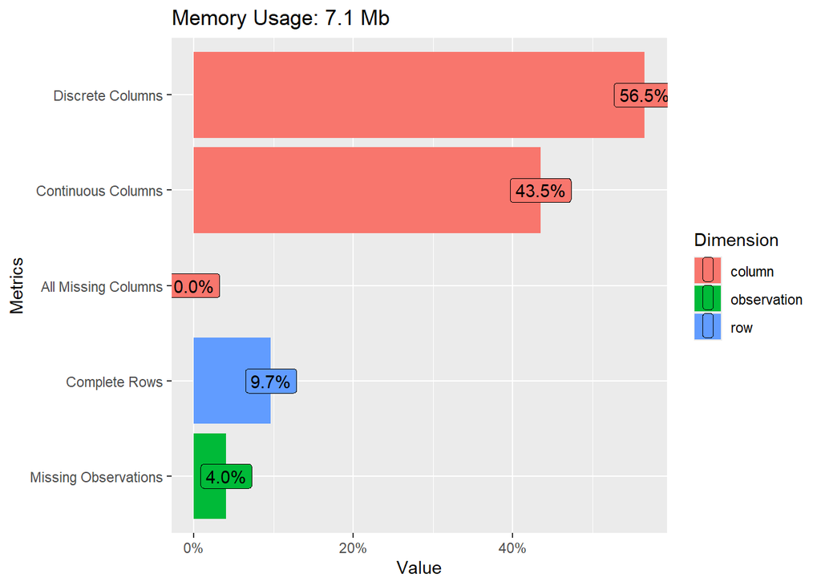

```r
plot_intro(data)
```

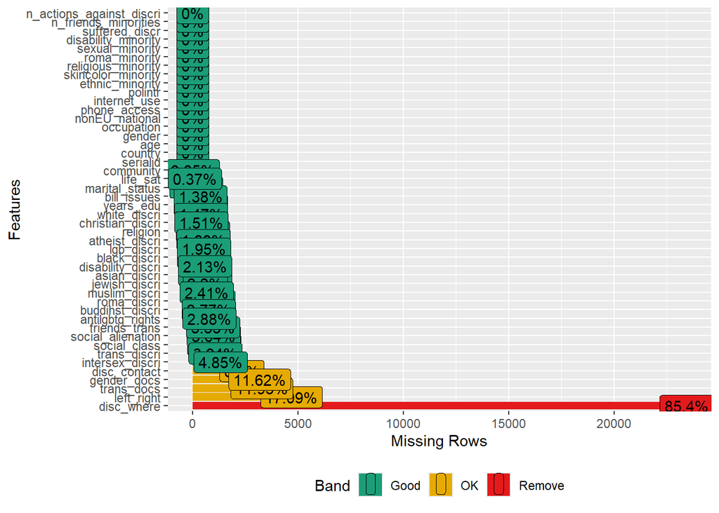

```r
plot_missing(data)
```

The total number of missing observations is quite low (4%) so missing data should not be a huge problem

Given the high percentage of missing values we delete `disc_where`. This variable was expected to have a high percentage of missingness as it is a question that applies only to people that have been subject to discrimination.

The variable with the second highest number of missing data is `left_right`, given the importance of this variable it is probably worth to impute those values.

Next there are the variables `trans_docs` and `gender_docs` which are respectively our target variable and a closely related variable

Then there is `disc_contact` which will be deleted as well, given that it does not add meaningful information to our analysis

```r
data <- data |>
  select(-c("disc_where", "disc_contact"))
```

# Exploratory Data Analysis

Plotting the distribution of the numeric variables

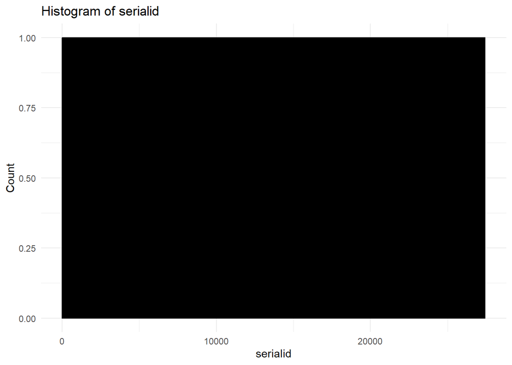

```
## Skewness of serialid : 0
```

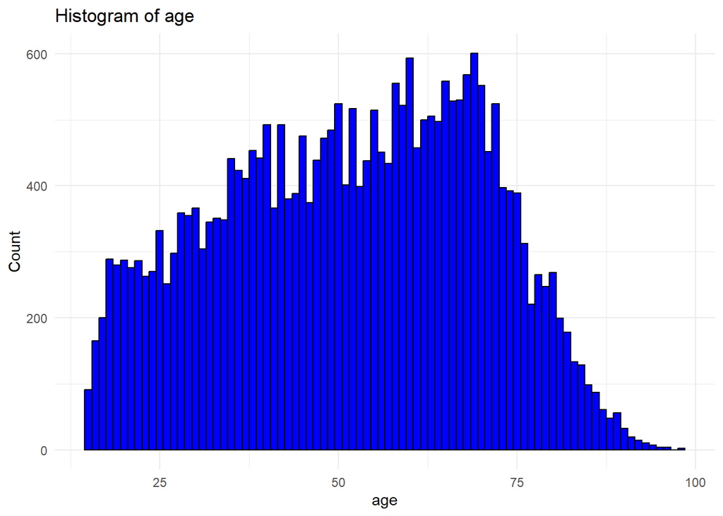

```
## Skewness of age : -0.1189211
```

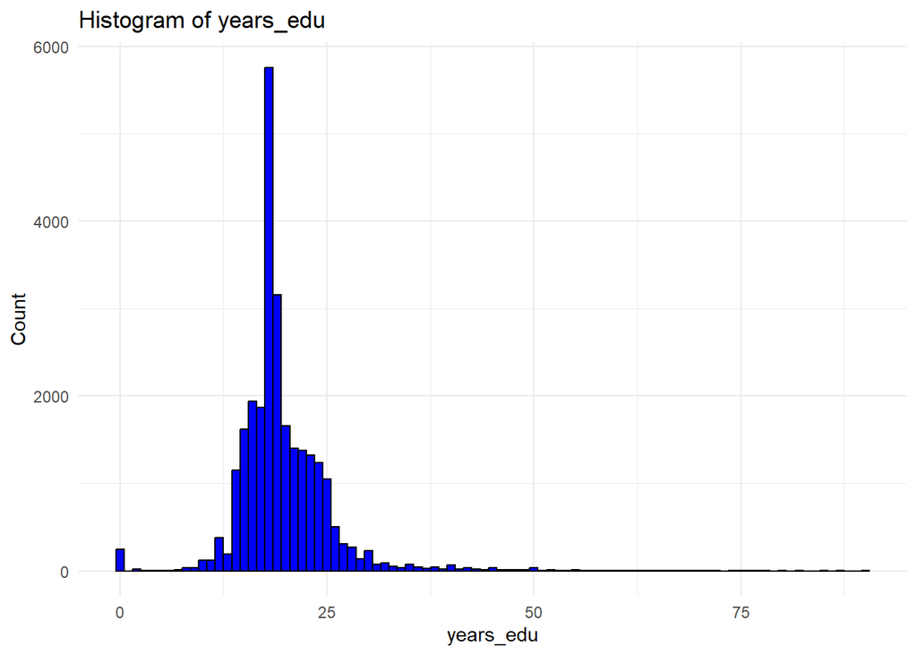

```
## Skewness of years_edu : 2.379305
## --> Consider applying a logarithmic transformation to years_edu
```

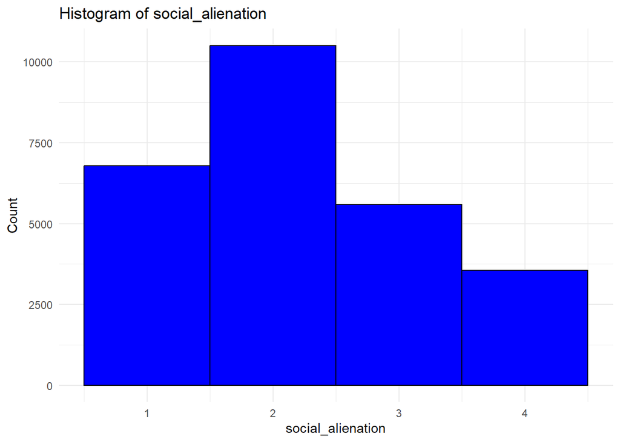

```
## Skewness of social_alienation : 0.2702432
```

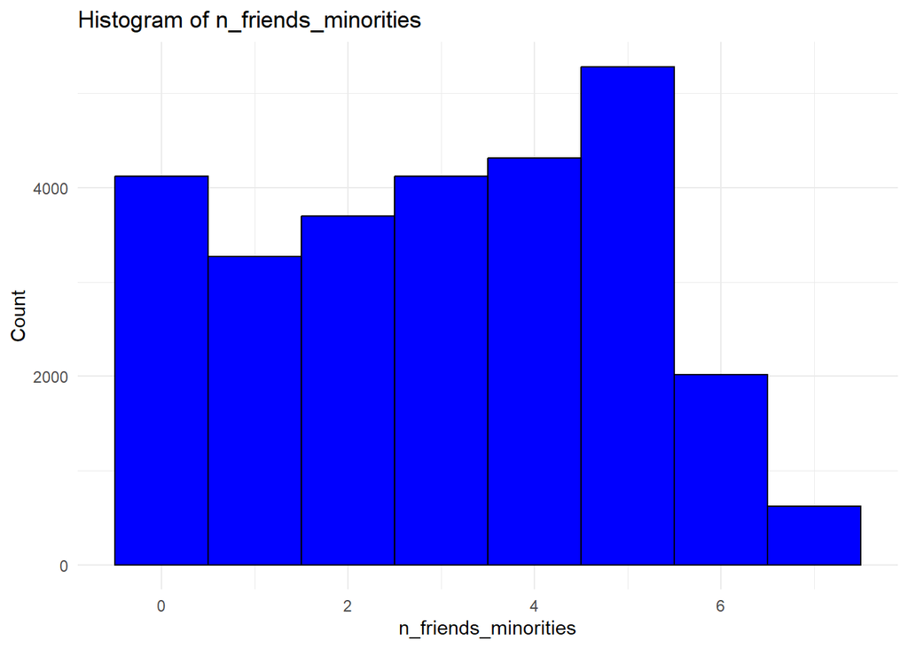

```
## Skewness of n_friends_minorities : -0.04656275
```

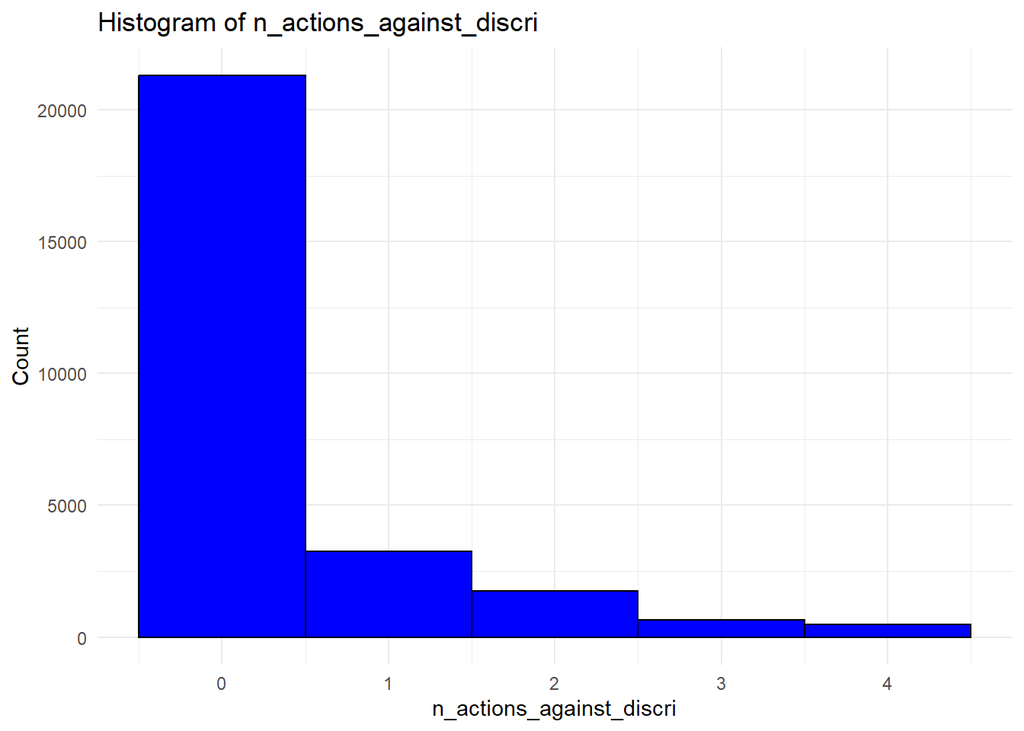

```
## Skewness of n_actions_against_discri : 2.466341
## --> Consider applying a logarithmic transformation to n_actions_against_discri
```

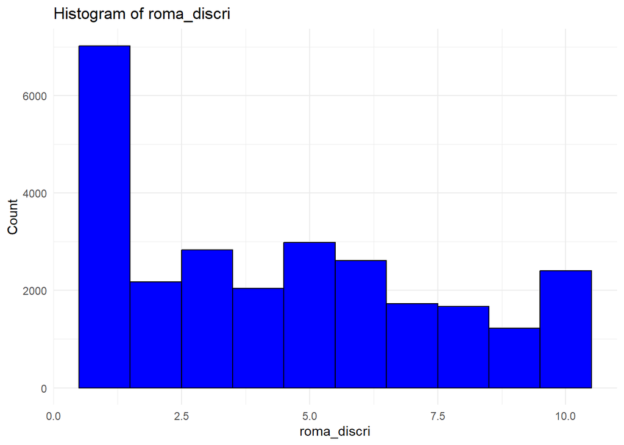

```
## Skewness of roma_discri : 0.3302414
```

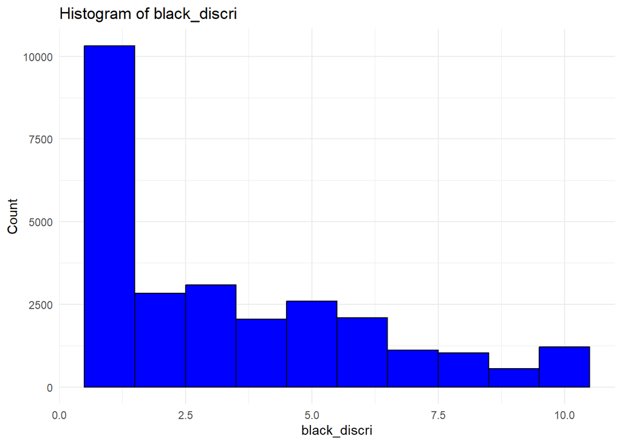

```
## Skewness of black_discri : 0.8274431
```

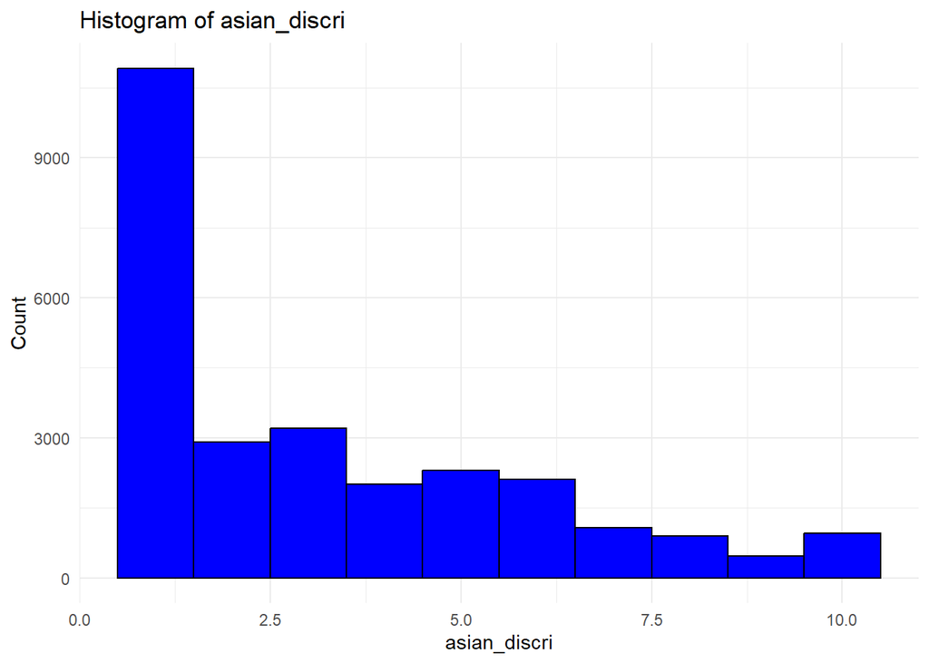

```
## Skewness of asian_discri : 0.9145309
```

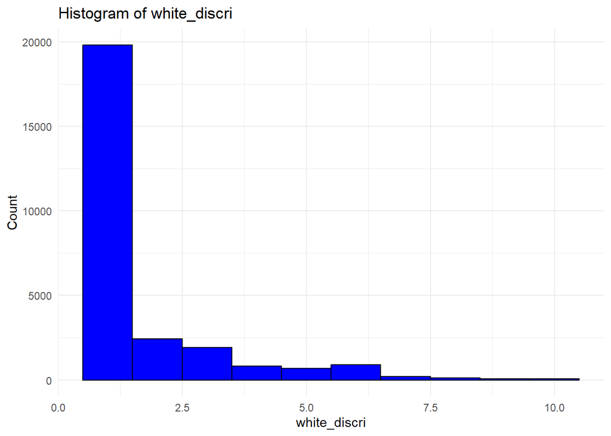

```
## Skewness of white_discri : 2.363763
## --> Consider applying a logarithmic transformation to white_discri
```

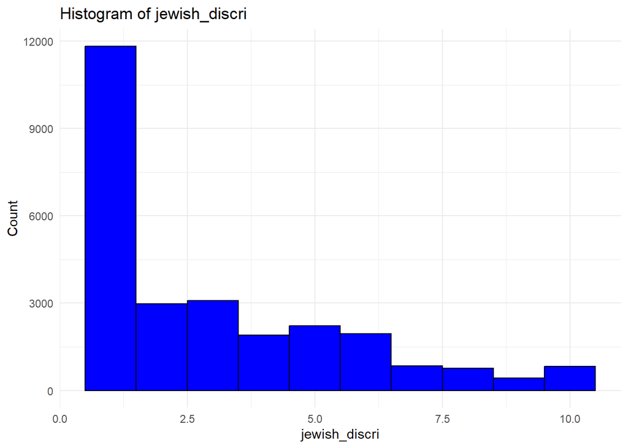

```
## Skewness of jewish_discri : 1.047646
## --> Consider applying a logarithmic transformation to jewish_discri
```

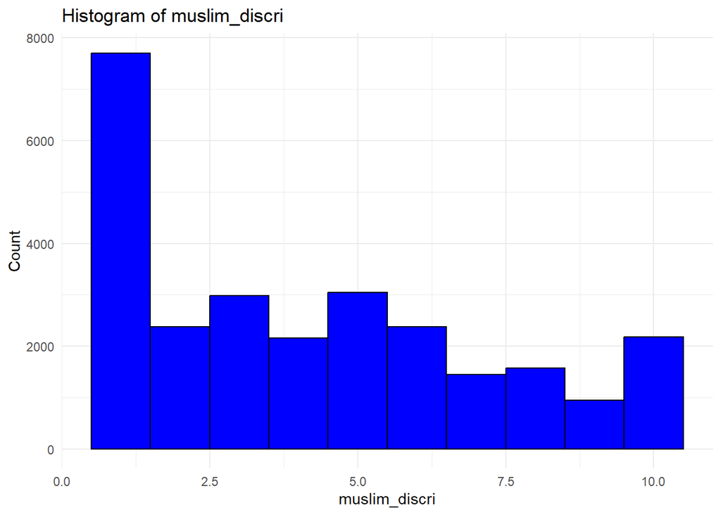

```
## Skewness of muslim_discri : 0.4638859
```

[8 more figures not shown]

```
## Skewness of antilgbtq_rights : 0.4429458
```

```r
library(e1071)

# Identify numeric variables
numeric_vars <- names(data)[sapply(data, is.numeric)]

# Creating histogramas y calculating skweness
for (var in numeric_vars) {
  p <- ggplot(data, aes(x = .data[[var]])) +
    geom_histogram(binwidth = 1, fill = "blue", color = "black") +
    labs(title = paste("Histogram of", var), x = var, y = "Count") +
    theme_minimal()
  print(p)

  skew <- skewness(data[[var]], na.rm = TRUE)
  cat("Skewness of", var, ":", skew, "\n")

  # Suggest transformation if skeness is high
  if (abs(skew) > 1) {
    cat("--> Consider applying a logarithmic transformation to", var, "\n")
  }
}
```

## Analysis of individual-level variables

We must keep in mind our Target variable is qc19 “Do you think that transgender persons should be able to change their civil documents to match their inner gender identity?”

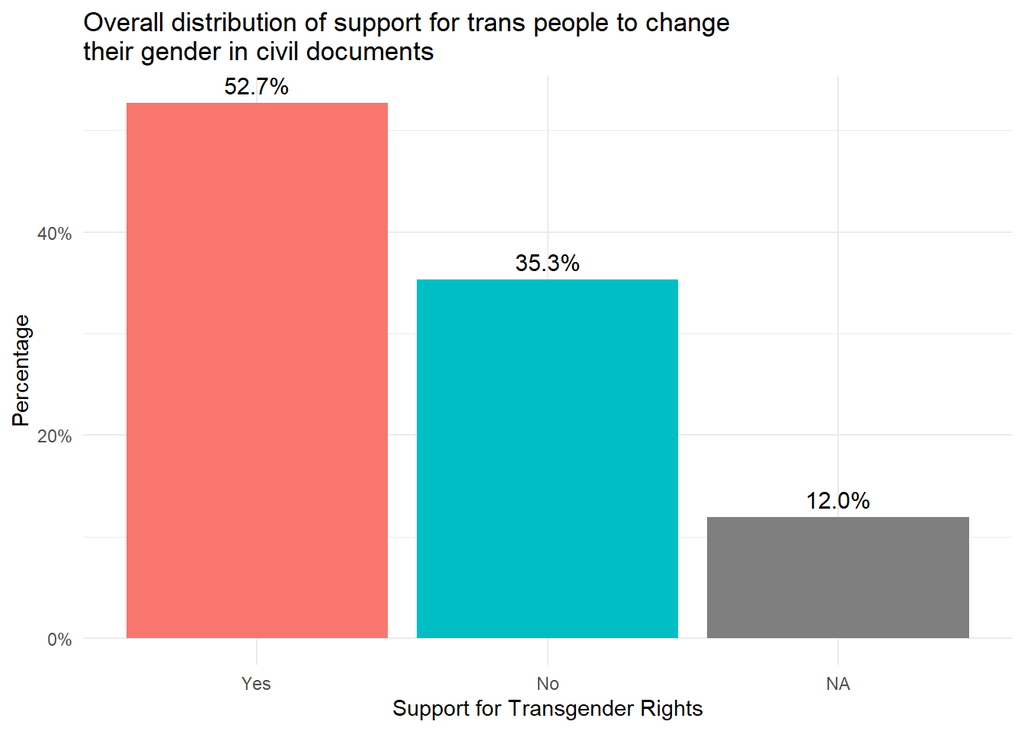

```r
data_percent <- data |>
  group_by(trans_docs) |>
  summarise(count = n()) |>
  mutate(percentage = count / sum(count) * 100)

ggplot(data_percent, aes(x = trans_docs, y = percentage, fill = trans_docs)) +
  geom_bar(stat = "identity") +
  geom_text(aes(label = sprintf("%.1f%%", percentage)),
            vjust = -0.5, size = 4, color = "black") +
  scale_y_continuous(labels = scales::percent_format(scale = 1)) +
  labs(
    title = "Overall distribution of support for trans people to change \ntheir gender in civil documents",
    x = "Support for Transgender Rights",
    y = "Percentage"
  ) +
  theme_minimal() +
  theme(legend.position = "none")
```

Taking a look to our variable of interest alone, we see how the 52.7% of our sample are in favor of trans people to change their gender in their civil documents. However, there is also a significant opposition (35,3%), and a 12% who answered “Don’t know”. We will try to explore this distribution along the variables we consider to be most important for our analysis.

–> When we turned DK into NAs for all the factor variables, we also changed it for qc19 (now trans_docs). We should keep throughout our analysis in mind that NAs for qc19 are actually DK. Later we can code it as DK instead of NAs to have better graphs.

### Sociodemographic variables

#### Gender

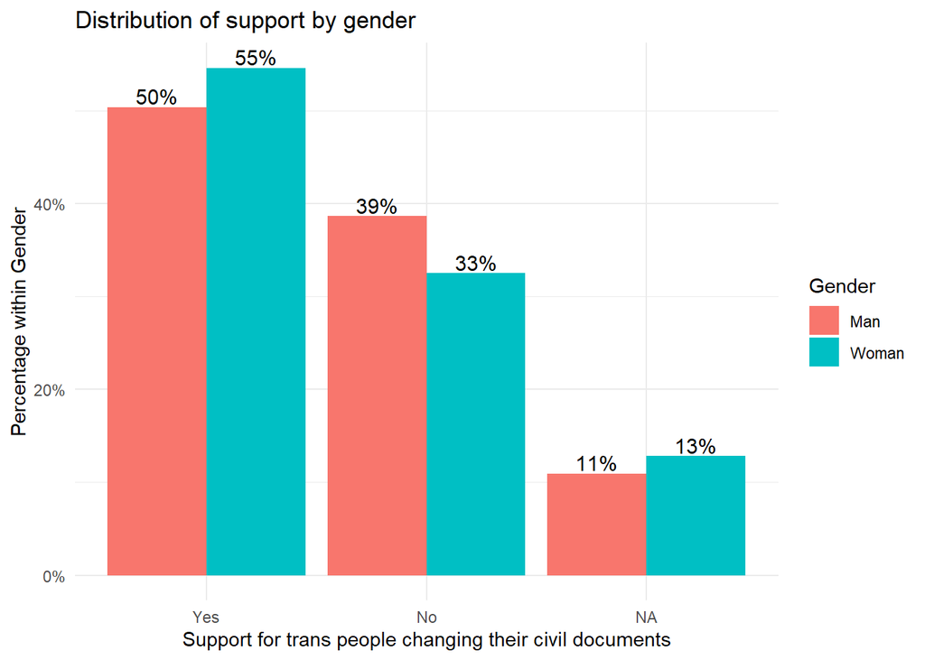

```r
data_summary <- data |>
  count(trans_docs, gender, name = "n") |>
  group_by(gender) |>
  mutate(percentage = n / sum(n))

ggplot(data_summary, aes(x = trans_docs, y = percentage, fill = gender)) +
  geom_bar(stat = "identity", position = "dodge") +
  geom_text(aes(label = scales::percent(percentage, accuracy = 1)),
            position = position_dodge(width = 0.9), vjust = -0.2, size = 4) +
  scale_y_continuous(labels = percent_format()) +
  labs(
    title = "Distribution of support by gender",
    x = "Support for trans people changing their civil documents",
    y = "Percentage within Gender",
    fill = "Gender"
  ) +
  theme_minimal()
```

```r
# Crear una tabla de contingencia
contingency_table <- table(data$gender, data$trans_docs)

# Realizar la prueba de chi-cuadrado
chisq_test <- chisq.test(contingency_table)
print(chisq_test)
```

```
##
##  Pearson's Chi-squared test with Yates' continuity correction
##
## data:  contingency_table
## X-squared = 92.715, df = 1, p-value < 2.2e-16
```

Men exhibit a lower percentage of favorable or dk responses and a higher rate of rejection compared to women. There is a statistically significant association between gender and our target variable, being women more supportive

#### Age

```r
#ANOVA
anova <- aov(age ~ trans_docs, data = data)
summary(anova)
```

```
##                Df  Sum Sq Mean Sq F value Pr(>F)
## trans_docs      1   24223   24223   74.81 <2e-16 ***
## Residuals   24156 7821139     324
## ---
## Signif. codes:  0 '***' 0.001 '**' 0.01 '*' 0.05 '.' 0.1 ' ' 1
## 3280 observations deleted due to missingness
```

There are significant differences between the groups defined by trans_docs.

#### Religiosity

We have two variables related to religiosity: religion (the religious affiliation professed by the respondent) and religious_minority (whether or not the respondent belongs to a religious minority group).

For the first one it’s better to show a cross table instead of a plot, since there are a lot of categories

```r
CrossTable(data$religion, data$trans_docs,
           digits = 2,
           expected = FALSE,
           asresid = TRUE,
           chisq = TRUE,
           prop.chisq = FALSE,
           format = "SPSS")
```

```
##
##    Cell Contents
## |-------------------------|
## |                   Count |
## |             Row Percent |
## |          Column Percent |
## |           Total Percent |
## |           Adj Std Resid |
## |-------------------------|
##
## Total Observations in Table:  23792
##
##                    | data$trans_docs
##      data$religion |      Yes  |       No  | Row Total |
## -------------------|-----------|-----------|-----------|
##           Catholic |     5605  |     4241  |     9846  |
##                    |    56.93% |    43.07% |    41.38% |
##                    |    39.27% |    44.55% |           |
##                    |    23.56% |    17.83% |           |
##                    |    -8.09  |     8.09  |           |
## -------------------|-----------|-----------|-----------|
## Orthodox Christian |     1421  |     1959  |     3380  |
##                    |    42.04% |    57.96% |    14.21% |
##                    |     9.96% |    20.58% |           |
##                    |     5.97% |     8.23% |           |
##                    |   -22.99  |    22.99  |           |
## -------------------|-----------|-----------|-----------|
##         Protestant |     1866  |      807  |     2673  |
##                    |    69.81% |    30.19% |    11.23% |
##                    |    13.07% |     8.48% |           |
##                    |     7.84% |     3.39% |           |
##                    |    11.00  |   -11.00  |           |
## -------------------|-----------|-----------|-----------|
##    Other Christian |      597  |      449  |     1046  |
##                    |    57.07% |    42.93% |     4.40% |
##                    |     4.18% |     4.72% |           |
##                    |     2.51% |     1.89% |           |
##                    |    -1.97  |     1.97  |           |
## -------------------|-----------|-----------|-----------|
##              Other |      764  |      446  |     1210  |
```

[output cut: 17 more lines]

```
##       Column Total |    14272  |     9520  |    23792  |
##                    |    59.99% |    40.01% |           |
## -------------------|-----------|-----------|-----------|
##
##
## Statistics for All Table Factors
##
##
## Pearson's Chi-squared test
## ------------------------------------------------------------
## Chi^2 =  973.2956     d.f. =  6     p =  5.330102e-207
##
##
##
##        Minimum expected frequency: 127.6429
```

Out of all observations Catholic, non-believers, Orthodox Christians and Protestants sum up to the 81.04% of our sample, being the rest underrepresented.

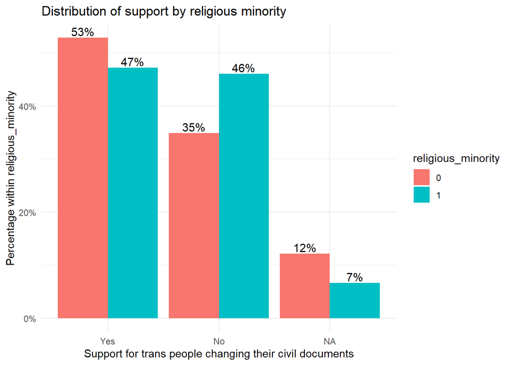

```r
data_summary <- data |>
  count(trans_docs, religious_minority, name = "n") |>
  group_by(religious_minority) |>
  mutate(percentage = n / sum(n))

ggplot(data_summary, aes(x = trans_docs, y = percentage, fill = religious_minority)) +
  geom_bar(stat = "identity", position = "dodge") +
  geom_text(aes(label = scales::percent(percentage, accuracy = 1)),
            position = position_dodge(width = 0.9), vjust = -0.2, size = 4) +
  scale_y_continuous(labels = percent_format()) +
  labs(
    title = "Distribution of support by religious minority",
    x = "Support for trans people changing their civil documents",
    y = "Percentage within religious_minority",
    fill = "religious_minority"
  ) +
  theme_minimal()
```

#### Ideology

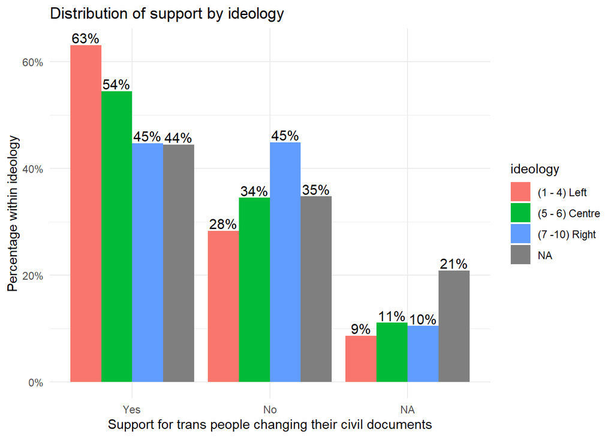

```r
data_summary <- data |>
  count(trans_docs, left_right, name = "n") |>
  group_by(left_right) |>
  mutate(percentage = n / sum(n))

ggplot(data_summary, aes(x = trans_docs, y = percentage, fill = left_right)) +
  geom_bar(stat = "identity", position = "dodge") +
  geom_text(aes(label = scales::percent(percentage, accuracy = 1)),
            position = position_dodge(width = 0.9), vjust = -0.2, size = 4) +
  scale_y_continuous(labels = percent_format()) +
  labs(
    title = "Distribution of support by ideology",
    x = "Support for trans people changing their civil documents",
    y = "Percentage within ideology",
    fill = "ideology"
  ) +
  theme_minimal()
```

Stronger left-wing support for trans rights. Right-wing respondents are the most divided, with high opposition levels. Non-responses are highest among those without ideological alignment.

#### Social class

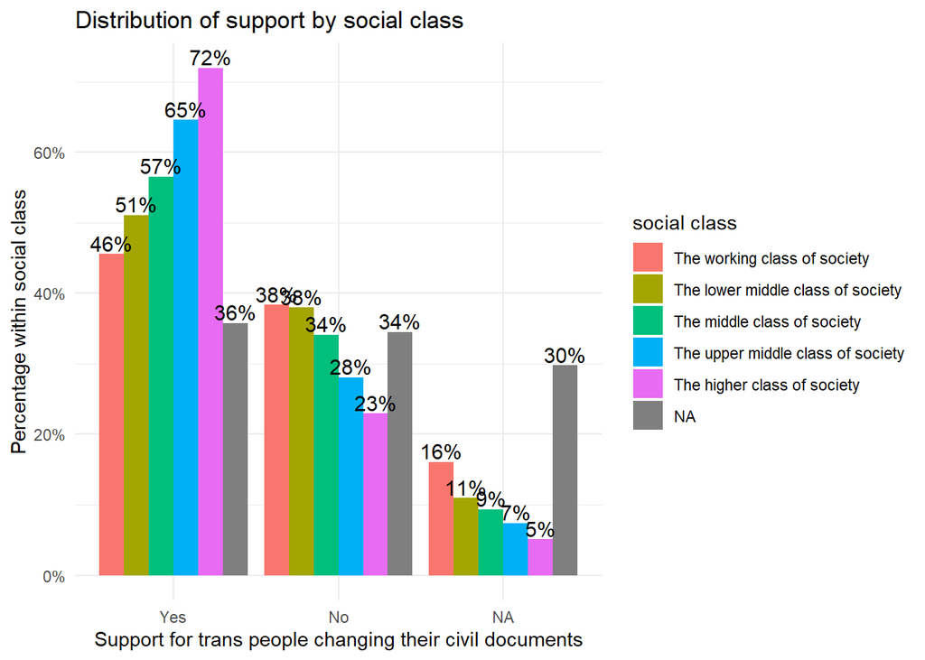

```r
data_summary <- data |>
  count(trans_docs, social_class, name = "n") |>
  group_by(social_class) |>
  mutate(percentage = n / sum(n))

ggplot(data_summary, aes(x = trans_docs, y = percentage, fill = social_class)) +
  geom_bar(stat = "identity", position = "dodge") +
  geom_text(aes(label = scales::percent(percentage, accuracy = 1)),
            position = position_dodge(width = 0.9), vjust = -0.2, size = 4) +
  scale_y_continuous(labels = percent_format()) +
  labs(
    title = "Distribution of support by social class",
    x = "Support for trans people changing their civil documents",
    y = "Percentage within social class",
    fill = "social class"
  ) +
  theme_minimal()
```

Although D63 of the questionnaire measures (oneself’s and one’s household’s) self-perceived social class, it is still a relevant and seemingly divisive variable. We observe a positive correlation, where support grows with increasing (perceived) social class, while explicit lack of support and no response are higher for lower-class individuals.

#### Education

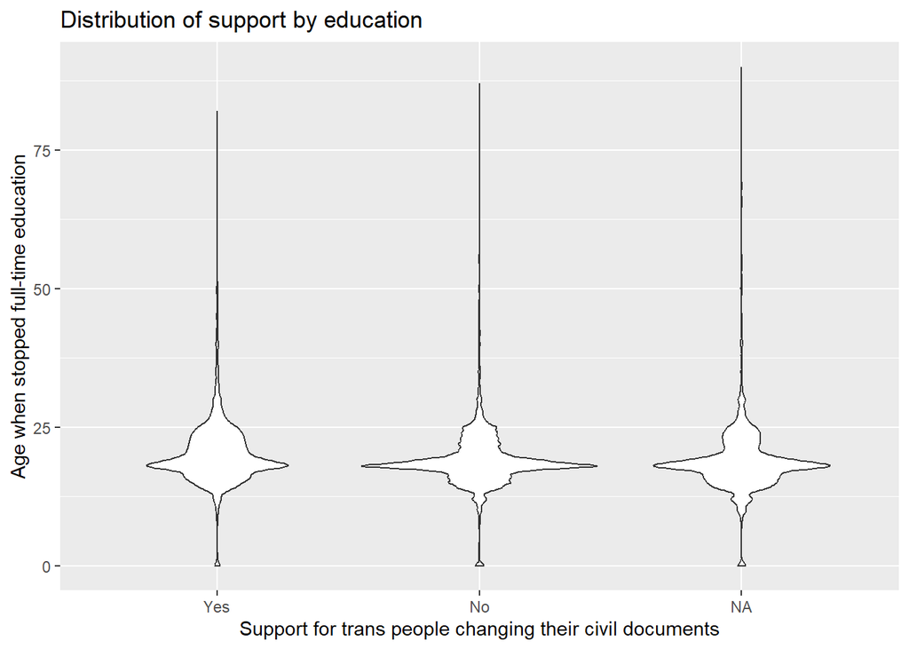

```r
ggplot(data, aes(x = trans_docs, y = years_edu)) +
  geom_violin() +
  labs(x = "Support for trans people changing their civil documents", y = "Age when stopped full-time education") +
  ggtitle("Distribution of support by education")
```

Support doesn’t seem to be related to education.

#### Area of residence

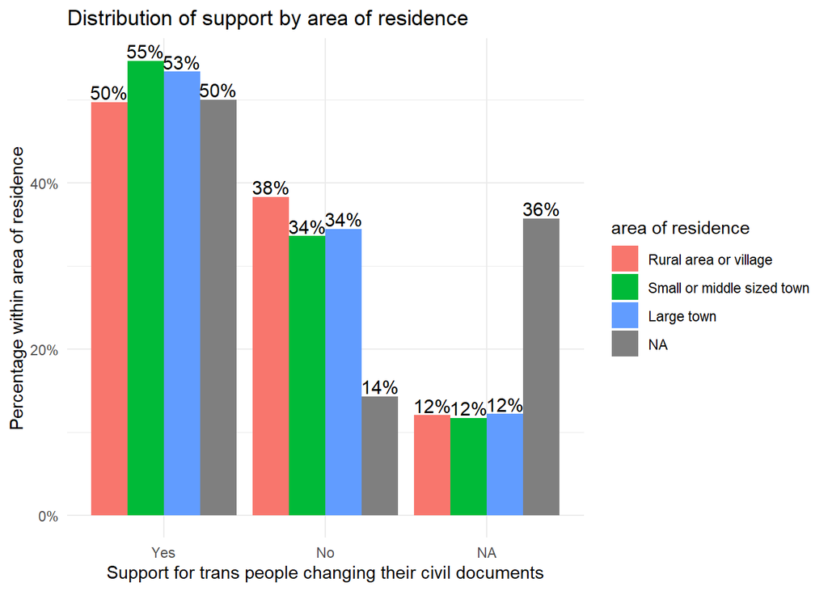

```r
data_summary <- data |>
  count(trans_docs, community, name = "n") |>
  group_by(community) |>
  mutate(percentage = n / sum(n))

ggplot(data_summary, aes(x = trans_docs, y = percentage, fill = community)) +
  geom_bar(stat = "identity", position = "dodge") +
  geom_text(aes(label = scales::percent(percentage, accuracy = 1)),
            position = position_dodge(width = 0.9), vjust = -0.2, size = 4) +
  scale_y_continuous(labels = percent_format()) +
  labs(
    title = "Distribution of support by area of residence",
    x = "Support for trans people changing their civil documents",
    y = "Percentage within area of residence",
    fill = "area of residence"
  ) +
  theme_minimal()
```

Support does not vary much by area of residence.

### Other individual-level variables

#### Having trans friends

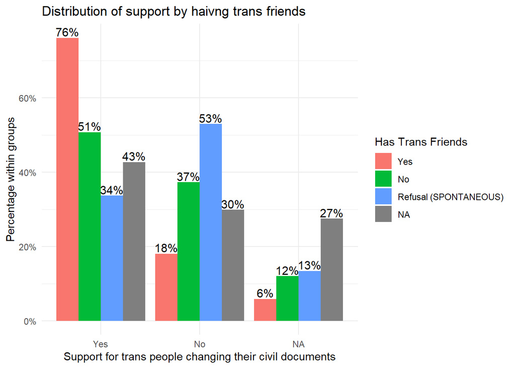

```r
data_summary <- data |>
  count(trans_docs, friends_trans, name = "n") |>
  group_by(friends_trans) |>
  mutate(percentage = n / sum(n))

ggplot(data_summary, aes(x = trans_docs, y = percentage, fill = friends_trans)) +
  geom_bar(stat = "identity", position = "dodge") +
  geom_text(aes(label = scales::percent(percentage, accuracy = 1)),
            position = position_dodge(width = 0.9), vjust = -0.2, size = 4) +
  scale_y_continuous(labels = percent_format()) +
  labs(
    title = "Distribution of support by haivng trans friends",
    x = "Support for trans people changing their civil documents",
    y = "Percentage within groups",
    fill = "Has Trans Friends"
  ) +
  theme_minimal()
```

Having trans friends is associated with a higher support, while those who refuse to disclose their connections to trans people tend to oppose more.

## Country-level data

Replication of the plot in Marga’s document. This is probably not needed in the final version of the document.

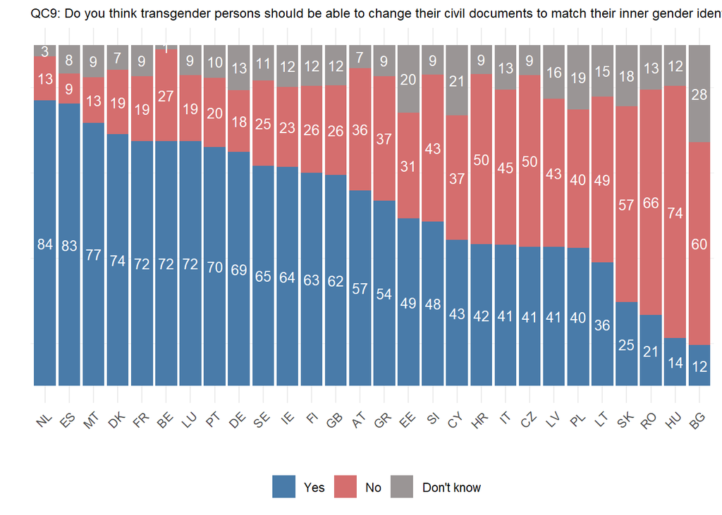

```r
country_support <- data %>%
  mutate(
    trans_docs = case_when(
      is.na(trans_docs) ~ "DK",
      trans_docs == "Yes" ~ "1",
      trans_docs == "No" ~ "2",
      TRUE ~ as.character(trans_docs)
    )
  ) %>%
  group_by(country, trans_docs = trans_docs) %>%
  summarise(count = n(), .groups = "drop") %>%
  group_by(country) %>%
  mutate(proportion = (count / sum(count))*100) %>%
  ungroup()

ggplot(country_support, aes(x = factor(country, levels = country_support %>%
                                       filter(trans_docs == "1") %>%
                                       arrange(desc(proportion)) %>%
                                       pull(country)),
                           y = proportion,
                           fill = factor(trans_docs, levels = c("1", "2", "DK")))) +
  geom_bar(stat = "identity", position = position_stack(reverse = TRUE)) +
  scale_fill_manual(values = c("1" = "#497ba9", "2" = "#d56e6e", "DK" = "#9a9595"),
                   name = "",
                   labels = c("Yes", "No", "Don't know")) +
  geom_text(aes(label = round(proportion)),
          position = position_stack(reverse = TRUE, vjust = 0.5),
          size = 3.5, color = "white") +
  labs(
    title = "QC9: Do you think transgender persons should be able to change their civil documents to match their inner gender identity?",
    x = "",
    y = ""
  ) +
  theme_minimal() +
  theme(axis.text.x = element_text(angle = 45, hjust = 1),
        axis.text.y = element_blank(),
        axis.ticks.y = element_blank(),
        plot.title = element_text(size = 9),
        panel.grid.major.y = element_blank(),
        legend.position = "bottom")
```

There are some mismatches, I guess the data might have become distorted at some point during processing, but I don’t know when.

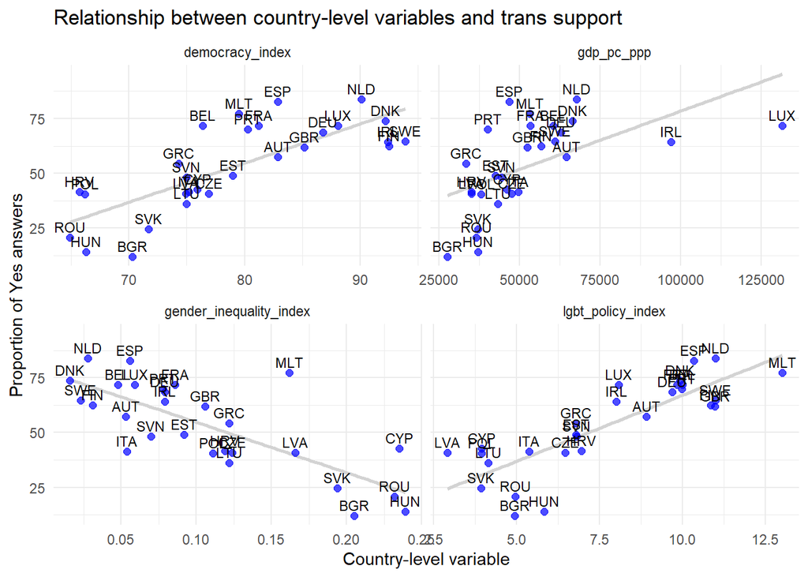

```r
trans_docs_prop <- country_support %>%
  filter(trans_docs == "1") %>%
  select(country, proportion) %>%
  rename(trans_support = proportion)

country_long <- country_level_data %>%
  inner_join(trans_docs_prop, by = c("iso2c" = "country")) |>
  pivot_longer(cols = c(gdp_pc_ppp, gender_inequality_index, lgbt_policy_index, democracy_index),
    names_to = "variable", values_to = "value")

ggplot(country_long, aes(x = value, y = trans_support)) +
  geom_smooth(method = "lm", se = FALSE, color = "lightgray") + # we can remove this
  geom_point(size = 2, color = "blue", alpha = 0.7) +
  geom_text(aes(label = iso3c), vjust = -0.5, hjust = 0.5, size = 3) +
  facet_wrap(~variable, scales = "free_x") +
  labs(
    title = "Relationship between country-level variables and trans support",
    x = "Country-level variable",
    y = "Proportion of Yes answers"
  ) +
  theme_minimal()
```

Democracy and LGBT Policy indeces seem to have a positive linear relationship with the target variable, while Gender Inequality index has a negative linear relationship. The relationship with GDP per capita is non-linear (logarithmic?). There appears to be a “ceiling” of support, beyond which increases in GDP per capita lose effect.

Boxplots for country-level variables:

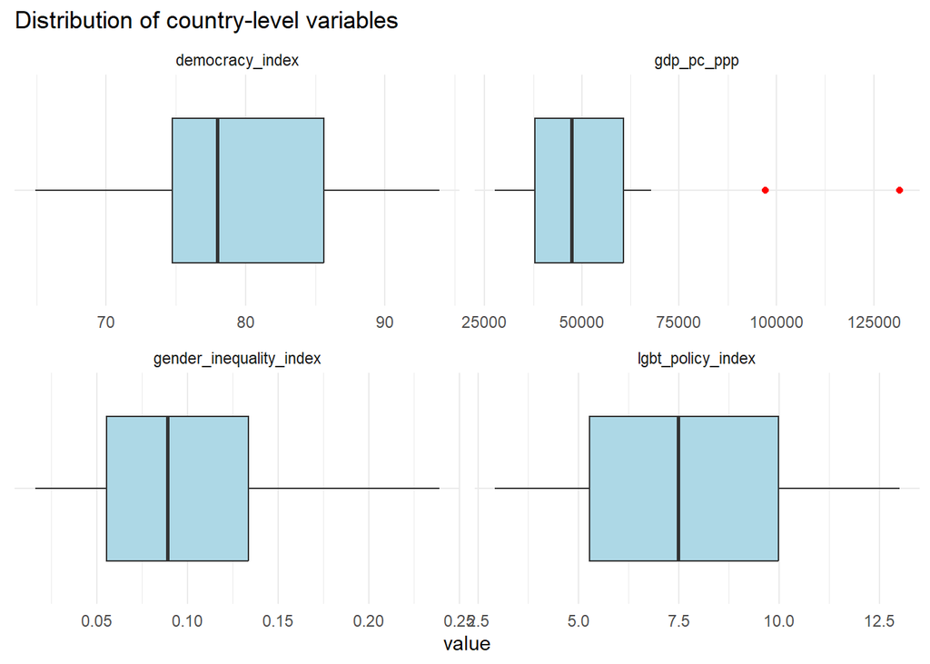

```r
ggplot(country_long, aes(y = value, x = variable)) +
  geom_boxplot(outlier.color = "red", outlier.shape = 16, fill = "lightblue") +
  coord_flip() +
  theme_minimal() +
  labs(title = "Distribution of country-level variables", x = NULL, y = "value") +
  facet_wrap(~variable, scales = "free") +
  theme(axis.text.y = element_blank(),
        axis.ticks.x = element_blank())
```

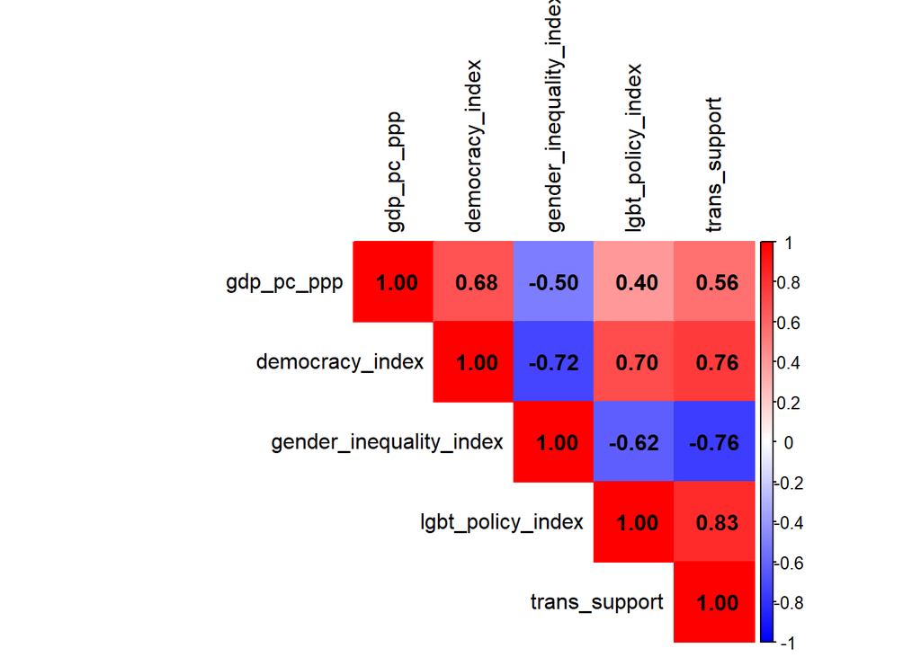

```r
country_level_data <- country_level_data %>%
  inner_join(trans_docs_prop, by = c("iso2c" = "country"))

cor_matrix <- cor(country_level_data %>%
                    select(gdp_pc_ppp, democracy_index, gender_inequality_index,
                           lgbt_policy_index, trans_support),
                  use = "complete.obs")

corrplot(cor_matrix, method = "color", type = "upper",
         addCoef.col = "black", tl.col = "black",
         col = colorRampPalette(c("blue", "white", "red"))(200))
```

Some heavy correlations which is a little worrying, but as we are going to use these data to build cross-level interactions, this should not compromise the reliability of our analysis too much.